# Final Project Analysis

Gabriella Noreen

2024-12-11

# 1 Data Wrangling

## 1.1 Initial call of the data

Note: This calls core variables only, not including IQ data or GPA data [see below]

```r
rm(list=ls(all=TRUE))
library(tidyverse)
library(ggplot2)
library(corrplot)
library(caret)
library(psych)
library(factoextra) #extract and visualize the output of multivariate data analyses, including 'PCA'
nlsy_core <- read.csv("NLSY_CORE.csv") # Read in dataset with initial variables pulled


# Read in data on marital status
# (also contains information on the number of kids in the HH in 1999
# and whether the participant had a child before their first marriage)
nlsy_marriage <- read.csv("NLSY_marriage_kids1999.csv") %>%
  # remove redundant demographic variables (sex, race, etc.)
  dplyr::select(-R0173600, -R0214700, -R0214800, -R6486300) %>%
  filter(R6479300 < 2) # filter only those who are married or unmarried

# Provide more descriptive names
colnames(nlsy_marriage) <- c("R0000100",
                         "Marital_Status", # 0 never married, 1 married
                         "Num_Kids_HH", # Number of kids in hh
                         "Child_b4_marriage") # 0 child b4 marriage, 1 marriage b4 1st child
nlsy_marriage <- nlsy_marriage %>%
  # remove variables based on decision to look at 2009 income and children
  dplyr::select(-Num_Kids_HH, -Child_b4_marriage)

nlsy_core <- left_join(nlsy_core, nlsy_marriage) # merge marrige indicator into core file


# Read in file for number of kids in HH in 2009 (when income data was examined)
nlsy_kids2009 <- read.csv("NLSY_kids2009.csv")

# improve column name for data on kids in HH in 2009
colnames(nlsy_kids2009) <- c("R0000100",
                         "Num_Kids_HH")

# Merge number of children variable with core dataset
nlsy_core <- left_join(nlsy_core, nlsy_kids2009)


# Negative values indicate missing, convert to NA
nlsy_core[nlsy_core < 0] <- NA

dim(nlsy_core) # Current dimensions
```

```
## [1] 12686    65
```

## 1.2 Create IQ composite

Since there were up to 11 IQ scores reported (and possible inconsistency in scoring systems), a composite of the IQ percentile rank was created for each participant. For any number of IQ scores and corresponding percentile reported for each participant, the average IQ percentile rank was calculated.

```r
nlsy_IQ <- read.csv("NLSY_IQ.csv") # Call in data with IQ composite variables

nlsy_IQ[nlsy_IQ < 0] <- NA # Convert negative values to NA (indicates skipped/missing data)

# Select ID and percentile variables
nlsy_IQ <- nlsy_IQ %>%
            dplyr::select(R0000100, R0017312, R0017317, R0017322, R0017327, R0017332, R0017337, R0017342,
                   R0017347, R0017352, R0017388, R0017394)

# Calculate row means for each percentile rank reported (skipping over the ID column (i.e., [,-1]))
nlsy_IQ$avg_IQ_percentile <- rowMeans(nlsy_IQ[,-1], na.rm = TRUE)

# Convert the NaNs to NAs
nlsy_IQ <- nlsy_IQ %>% mutate_all(~ifelse(is.nan(.), NA, .))

nlsy_IQ_complete <- nlsy_IQ %>%
                     dplyr::select(R0000100, avg_IQ_percentile) # Select only ID column and average percentile to join

# Take a peek at the IQ composite variable
head(nlsy_IQ_complete)
```

```
##   R0000100 avg_IQ_percentile
## 1        1                NA
## 2        2                NA
## 3        3                NA
## 4        4                NA
## 5        5                99
## 6        6                NA
```

```r
# Join average IQ percentile composite with core variables from above
nlsy <- left_join(nlsy_core, nlsy_IQ_complete, by = "R0000100")
nrow(nlsy)
```

```
## [1] 12686
```

## 1.3 Calculate GPA

The GPA data included the grade level the course was taken in, course code, grade received, source of information (final grade reported by school, year’s grades reported and averaged, or partial grades reported and averaged), and number of credits received for up to 64 courses per student. For ease of understanding the overall high school GPA for each student (and to maximize the information given since there were high amounts of missingness), the overall GPA was calculated as the average grade received across any number of courses reported.

```r
# Call in data with GPA variables
nlsy_GPA <- read.csv("NLSY_GPA.csv")

# For ease of analysis, pull the IDs from nlsy_core who had no errors on their transcript...
nlsy_no_error_ts <- nlsy_core %>%
                      dplyr::select(R0000100, R0620602) %>% # Select ID variable and transcript status variable
                      filter(R0620602 == 0) # Filter only those with no transcript errors noted

# Merge selected IDs with our GPA data
nlsy_GPA_noError <- left_join(nlsy_no_error_ts, nlsy_GPA, by = "R0000100") %>%
                      dplyr::select(-R0620602) # And drop the transcript status column

# Currently the data is in wide format, need it in long format to calculate GPA

# Need to rename the columns first before I pivot
colnames(nlsy_GPA_noError) <- c("R0000100",
                                "C1_Year","C1_CC","C1_Grade","C1_Source", "C1_Credit",
                                "C2_Year","C2_CC","C2_Grade","C2_Source", "C2_Credit",
                                "C3_Year","C3_CC","C3_Grade","C3_Source", "C3_Credit",
                                "C4_Year","C4_CC","C4_Grade","C4_Source", "C4_Credit",
                                "C5_Year", "C5_CC","C5_Grade","C5_Source", "C5_Credit",
                                "C6_Year", "C6_CC","C6_Grade","C6_Source", "C6_Credit",
                                "C7_Year", "C7_CC","C7_Grade","C7_Source", "C7_Credit",
                                "C8_Year", "C8_CC","C8_Grade","C8_Source", "C8_Credit",
                                "C9_Year", "C9_CC","C9_Grade","C9_Source", "C9_Credit",
                                "C10_Year", "C10_CC","C10_Grade","C10_Source", "C10_Credit",
                                "C11_Year", "C11_CC","C11_Grade","C11_Source", "C11_Credit",
                                "C12_Year", "C12_CC","C12_Grade","C12_Source", "C12_Credit",
                                "C13_Year", "C13_CC","C13_Grade","C13_Source", "C13_Credit",
                                "C14_Year", "C14_CC","C14_Grade","C14_Source", "C14_Credit",
                                "C15_Year", "C15_CC","C15_Grade","C15_Source", "C15_Credit",
                                "C16_Year", "C16_CC","C16_Grade","C16_Source", "C16_Credit",
                                "C17_Year", "C17_CC","C17_Grade","C17_Source", "C17_Credit",
                                "C18_Year", "C18_CC","C18_Grade","C18_Source", "C18_Credit",
                                "C19_Year", "C19_CC","C19_Grade","C19_Source", "C19_Credit",
                                "C20_Year", "C20_CC","C20_Grade","C20_Source", "C20_Credit",
                                "C21_Year", "C21_CC","C21_Grade","C21_Source", "C21_Credit",
                                "C22_Year", "C22_CC","C22_Grade","C22_Source", "C22_Credit",
                                "C23_Year", "C23_CC","C23_Grade","C23_Source", "C23_Credit",
                                "C24_Year", "C24_CC","C24_Grade","C24_Source", "C24_Credit",
                                "C25_Year", "C25_CC","C25_Grade","C25_Source", "C25_Credit",
                                "C26_Year", "C26_CC","C26_Grade","C26_Source", "C26_Credit",
                                "C27_Year", "C27_CC","C27_Grade","C27_Source", "C27_Credit",
                                "C28_Year", "C28_CC","C28_Grade","C28_Source", "C28_Credit",
                                "C29_Year", "C29_CC","C29_Grade","C29_Source", "C29_Credit",
                                "C30_Year", "C30_CC","C30_Grade","C30_Source", "C30_Credit",
                                "C31_Year", "C31_CC","C31_Grade","C31_Source", "C31_Credit",
                                "C32_Year", "C32_CC","C32_Grade","C32_Source", "C32_Credit",
                                "C33_Year", "C33_CC","C33_Grade","C33_Source", "C33_Credit",
                                "C34_Year", "C34_CC","C34_Grade","C34_Source", "C34_Credit",
                                "C35_Year", "C35_CC","C35_Grade","C35_Source", "C35_Credit",
                                "C36_Year", "C36_CC","C36_Grade","C36_Source", "C36_Credit",
                                "C37_Year", "C37_CC","C37_Grade","C37_Source", "C37_Credit",
                                "C38_Year", "C38_CC","C38_Grade","C38_Source", "C38_Credit",
                                "C39_Year", "C39_CC","C39_Grade","C39_Source", "C39_Credit",
                                "C40_Year", "C40_CC","C40_Grade","C40_Source", "C40_Credit",
                                "C41_Year", "C41_CC","C41_Grade","C41_Source", "C41_Credit",
                                "C42_Year", "C42_CC","C42_Grade","C42_Source", "C42_Credit",
                                "C43_Year", "C43_CC","C43_Grade","C43_Source", "C43_Credit",
                                "C44_Year", "C44_CC","C44_Grade","C44_Source", "C44_Credit",
                                "C45_Year", "C45_CC","C45_Grade","C45_Source", "C45_Credit",
                                "C46_Year", "C46_CC","C46_Grade","C46_Source", "C46_Credit",
                                "C47_Year", "C47_CC","C47_Grade","C47_Source", "C47_Credit",
                                "C48_Year", "C48_CC","C48_Grade","C48_Source", "C48_Credit",
                                "C49_Year", "C49_CC","C49_Grade","C49_Source", "C49_Credit",
                                "C50_Year", "C50_CC","C50_Grade","C50_Source", "C50_Credit",
                                "C51_Year", "C51_CC","C51_Grade","C51_Source", "C51_Credit",
                                "C52_Year", "C52_CC","C52_Grade","C52_Source", "C52_Credit",
                                "C53_Year", "C53_CC","C53_Grade","C53_Source", "C53_Credit",
                                "C54_Year", "C54_CC","C54_Grade","C54_Source", "C54_Credit",
                                "C55_Year", "C55_CC","C55_Grade","C55_Source", "C55_Credit",
                                "C56_Year", "C56_CC","C56_Grade","C56_Source", "C56_Credit",
                                "C57_Year", "C57_CC","C57_Grade","C57_Source", "C57_Credit",
                                "C58_Year", "C58_CC","C58_Grade","C58_Source", "C58_Credit",
                                "C59_Year", "C59_CC","C59_Grade","C59_Source", "C59_Credit",
                                "C60_Year", "C60_CC","C60_Grade","C60_Source", "C60_Credit",
                                "C61_Year", "C61_CC","C61_Grade","C61_Source", "C61_Credit",
                                "C62_Year", "C62_CC","C62_Grade","C62_Source", "C62_Credit",
                                "C63_Year", "C63_CC","C63_Grade","C63_Source", "C63_Credit",
                                "C64_Year", "C64_CC","C64_Grade","C64_Source", "C64_Credit")
# Pivot long
nlsy_GPA_noError_long <- nlsy_GPA_noError %>%
                            pivot_longer(-R0000100, names_to = c("Course_Number", ".value"),
                                         names_sep = "_") # why I needed those funky names above

# Remove rows where Grade = 6 ("Pass"), Note for others, 0 = E/F, 1 = D, 2 = C, 3 = B, 4 = A
# Credit is funky, so I'm going to remove that,
# I also can't find record of course codes, so will remove that too, also don't really need source...
nlsy_GPA_noError_long <- nlsy_GPA_noError_long %>% filter(Grade != 6) %>% dplyr::select(-Credit, -CC, -Source)

# Now, let's convert the negative values to NA, and remove them.
nlsy_GPA_noError_long[nlsy_GPA_noError_long < 0] <- NA
nlsy_GPA_noError_long <- nlsy_GPA_noError_long %>% drop_na(Grade)

# Calculate GPA by averaging all of the grades reported for each participant
nlsy_GPA_noError_CalcGPA <-
  nlsy_GPA_noError_long %>%
  group_by(R0000100) %>% # Group all courses within an individual's ID number
  summarise(
    GPA = mean(Grade) # Create new GPA variable
  )

# Take a peek at the GPA variable
head(nlsy_GPA_noError_CalcGPA)
```

```
## # A tibble: 6 × 2
##   R0000100   GPA
##      <int> <dbl>
## 1        5  3.39
## 2        8  2.24
## 3       11  3.33
## 4       12  2.67
## 5       14  3.25
## 6       15  2.66
```

```r
# Join with main dataset
nlsy <- left_join(nlsy, nlsy_GPA_noError_CalcGPA, by = "R0000100")
head(nlsy)
```

```
##   H0003200 H0003300 H0003400 R0000100 R0000300 R0000500 R0001800 R0006500
## 1       NA       NA       NA        1        9       58        1        8
## 2     5591     5587        2        2        1       59        1        5
## 3     1839     5608        4        3        8       61        1       10
## 4       NA       NA       NA        4        8       62        1       11
## 5       NA       NA       NA        5        7       59        1       12
## 6     5541     4096        3        6       10       60        1       12
##   R0007900 R0017302 R0017356 R0017358 R0017366 R0017367 R0017368 R0017379
## 1        8       NA       NA       NA       NA       NA       NA       NA
## 2        8       NA       NA       NA       NA       NA       NA       NA
## 3       12       NA       NA       NA       NA       NA       NA       NA
## 4       12       NA       NA       NA       NA       NA       NA       NA
## 5       12        0      976    40000        0       96        0        0
## 6       12       NA       NA       NA       NA       NA       NA       NA
##   R0017380 R0017381 R0017382 R0017383 R0017384 R0017385 R0214700 R0214800
```

[output cut: 48 more lines]

```r
dim(nlsy)
```

```
## [1] 12686    67
```

## 1.4 Finalizing the data

Adding in GPA completes the reading in of data. Next, meaningful names were updated (while still keeping the original variable name appended on the end for ease of reference to the codebook) to finalize the dataset (NLSY_F), and the cognitive ability indicator variable was created based on percentile rank for IQ, ACT, and SAT scores.

```r
# Remove variables I don't end up using
nlsy <- nlsy %>%
  dplyr::select(-T3489700, -T3047500, -R6911101, -R6917801,
                -R6919201, -T0309300, -T3056000, -T3058300,
                -T3977400, -H0003200, -H0003300, -H0003400,
                -R0017302,  -R0620601, -R0620602, -R0017384,
                -R0017385, -R0216701,-R0229200, -R0620400,
                -R0620300, -T0309000, -T3093500)

# Rename columns to provide more information and keep the original reference name
colnames(nlsy) <- c("ID_R0000100", "MthBrn_R0000300", "YrBrn_R0000500",
                    "Res14_R0001800", "HGCm_R0006500", "HGCf_R0007900",
                    "TotalEnrlmnt_R0017356", "NumBks_R0017358","PctDis_R0017366",
                    "PctAttnd_R0017367", "PctDO_R0017368","PctStuF_R0017379",
                    "PctFacF_R0017380","FTCouns_R0017381","FTFac_R0017382",
                    "PCTFTGradDeg_R0017383","Race_R0214700","Sex_R0214800",
                    "DaysAbs9_R0619100","DaysAbs10_R0619200", "DaysAbs11_R0619300",
                    "DaysAbs12_R0619400","Rank_R0619500","NumInClss_R0619600",
                    "PSAT_M_R0619700","PSAT_V_R0619800","SAT_M_R0619900","SAT_V_R0620000",
                    "ACT_M_R0620100","ACT_V_R0620200","RsnLeftSch_R0620500",
                    "FinTrnscpStatus_R0620600","HdSt_R4531700", "SelfInc1999_R6909701",
                    "FamInc1999_R7006500","PovSts1999_R7006600","HghstDeg_T2274100",
                    "SelfInc2009_T3045300","FamInc2009_T3107800","PovSts2009_T3108000",
                    "Marital_Status", "Num_Kids_HH",
                    "avg_IQ_percentile", "GPA")

# Mutate factors of interest and recode/relevel as needed
nlsy <- nlsy %>% filter(FinTrnscpStatus_R0620600 == 1) %>%
  # Pull those only with completed transcripts
  mutate(Sex_R0214800 = as.factor(Sex_R0214800)) %>%  # Convert sex to a factor
  mutate(Sex_R0214800 = recode(Sex_R0214800, "1" = 1, "2" = 0)) %>% # 1 = Male, 0 = Female
  mutate(HghstDeg_T2274100 = as.factor(HghstDeg_T2274100)) %>%
  # Convert highest degree obt. to factor
  # Recode highest degree obtained
  mutate(HghstDeg_T2274100 = recode(HghstDeg_T2274100, "0" = "None",
                                    "1" = "High School Diploma (or equivalent)",
                                    "2" = "Associate/Junior College",
                                    "3" = "Bachelor of Arts",
                                    "4" = "Bachelor of Science",
                                    "5" = "Master's Degree (MA, MBA, MS, MSW)",
                                    "6" = "Doctoral Degree (PhD)",
                                    "7" = "Professional Degree (MD, LLD, DDS)",
                                    "8" = "Other")) %>%
  filter(HghstDeg_T2274100 != "Other") %>%  # Remove non-informative "other" category
  mutate(HdSt_R4531700 = as.factor(HdSt_R4531700)) %>% # Convert and recode headstart variable
  # Combine days absent across HS career to single variable
  mutate(DaysAbsent = DaysAbs9_R0619100 + DaysAbs10_R0619200 +
           DaysAbs11_R0619300 + DaysAbs12_R0619400) %>%
  mutate(PovSts2009_T3108000 = as.factor(PovSts2009_T3108000)) %>%
  # Convert and recode poverty variable
  mutate(PovSts2009_T3108000 = recode(PovSts2009_T3108000,
                                  "0" = "Not In Poverty","1" = "In Poverty")) %>%
  # Convert and recode reason for leaving school variable and remove "other" category
  mutate(RsnLeftSch_R0620500 = as.factor(RsnLeftSch_R0620500)) %>%
  mutate(RsnLeftSch_R0620500 = recode(RsnLeftSch_R0620500, "1" = "Graduated",
                                      "2" = "Transferred", "3" = "Expelled",
                                      "4" = "Dropped Out", "5" = "Other",
                                      "6" = "Received a GED")) %>%
  mutate(Marital_Status = as.factor(Marital_Status)) %>%
  filter(RsnLeftSch_R0620500 != "Other")

dim(nlsy)
```

```
## [1] 5137   45
```

```r
# write.csv(nlsy, "NLSY_F.csv") # Write final CSV file to save

# nlsy <- read_csv("NLSY_F.csv") # Read in final data file

# nlsy <- nlsy[,-1] # Remove column of row names

####
### Prep for cognitive ability indicator based on percentile rank for IQ, ACT, or SAT
####
# Create ACT and SAT Composites
nlsy <- nlsy %>%
  mutate(ACT_Composite = (ACT_M_R0620100 + ACT_V_R0620200) / 2) %>%
  mutate(SAT_Composite = SAT_M_R0619900 + SAT_V_R0620000)

# Convert SAT to ACT
nlsy$SATtoACT_Convert <- ifelse(nlsy$SAT_Composite <= 580, 10,
                                ifelse(nlsy$SAT_Composite >= 590 & nlsy$SAT_Composite <= 670, 11,
                                ifelse(nlsy$SAT_Composite >= 680 & nlsy$SAT_Composite <= 730, 12,
                                ifelse(nlsy$SAT_Composite >= 740 & nlsy$SAT_Composite <= 770, 13,
                                ifelse(nlsy$SAT_Composite >= 780 & nlsy$SAT_Composite <= 820, 14,
                                ifelse(nlsy$SAT_Composite >= 830 & nlsy$SAT_Composite <= 860, 15,
                                ifelse(nlsy$SAT_Composite >= 870 & nlsy$SAT_Composite <= 900, 16,
                                ifelse(nlsy$SAT_Composite >= 910 & nlsy$SAT_Composite <= 940, 17,
                                ifelse(nlsy$SAT_Composite >= 950 & nlsy$SAT_Composite <= 980, 18,
                                ifelse(nlsy$SAT_Composite >= 990 & nlsy$SAT_Composite <= 1020, 19,
                                ifelse(nlsy$SAT_Composite >= 1030 & nlsy$SAT_Composite <= 1060, 20,
                                ifelse(nlsy$SAT_Composite >= 1070 & nlsy$SAT_Composite <= 1100, 21,
                                ifelse(nlsy$SAT_Composite >= 1110 & nlsy$SAT_Composite <= 1130, 22,
                                ifelse(nlsy$SAT_Composite >= 1140 & nlsy$SAT_Composite <= 1170, 23,
                                ifelse(nlsy$SAT_Composite >= 1070 & nlsy$SAT_Composite <= 1100, 21,
                                ifelse(nlsy$SAT_Composite >= 1180 & nlsy$SAT_Composite <= 1210, 24,
                                ifelse(nlsy$SAT_Composite >= 1220 & nlsy$SAT_Composite <= 1250, 25,
                                ifelse(nlsy$SAT_Composite >= 1260 & nlsy$SAT_Composite <= 1280, 26,
                                ifelse(nlsy$SAT_Composite >= 1290 & nlsy$SAT_Composite <= 1310, 27,
                                ifelse(nlsy$SAT_Composite >= 1320 & nlsy$SAT_Composite <= 1350, 28,
                                ifelse(nlsy$SAT_Composite >= 1360 & nlsy$SAT_Composite <= 1390, 29,
                                ifelse(nlsy$SAT_Composite >= 1400 & nlsy$SAT_Composite <= 1420, 30,
                                ifelse(nlsy$SAT_Composite >= 1430 & nlsy$SAT_Composite <= 1460, 31,
                                ifelse(nlsy$SAT_Composite >= 1470 & nlsy$SAT_Composite <= 1490, 32,
                                ifelse(nlsy$SAT_Composite >= 1500 & nlsy$SAT_Composite <= 1530, 33,
                                ifelse(nlsy$SAT_Composite >= 1540 & nlsy$SAT_Composite <= 1560, 34,
                                ifelse(nlsy$SAT_Composite >= 1570 & nlsy$SAT_Composite <= 1590, 35,
                                ifelse(nlsy$SAT_Composite == 1600, 36,
                                NA))))))))))))))))))))))))))))
# Merge converted SAT scores with ACT scores
nlsy$ACT_Full <- ifelse(!is.na(nlsy$ACT_Composite), nlsy$ACT_Composite,
                 ifelse(is.na(nlsy$ACT_Composite) &
                          !is.na(nlsy$SATtoACT_Convert), nlsy$SATtoACT_Convert,
                              NA))

# Given limited overlap in those with ACT/SAT scores and those with IQ scores...
# Convert standardized test scores to percentile and merge with IQ
nlsy$ACT_percentile <- ifelse(nlsy$ACT_Full >= 33, 99,
                              ifelse(nlsy$ACT_Full == 32, 98,
                              ifelse(nlsy$ACT_Full == 31, 96,
                              ifelse(nlsy$ACT_Full == 30, 95,
                              ifelse(nlsy$ACT_Full == 29, 92,
                              ifelse(nlsy$ACT_Full == 28, 90,
                              ifelse(nlsy$ACT_Full == 27, 87,
                              ifelse(nlsy$ACT_Full == 26, 83,
                              ifelse(nlsy$ACT_Full == 25, 79,
                              ifelse(nlsy$ACT_Full == 24, 74,
                              ifelse(nlsy$ACT_Full == 23, 68,
                              ifelse(nlsy$ACT_Full == 22, 63,
                              ifelse(nlsy$ACT_Full == 21, 56,
                              ifelse(nlsy$ACT_Full == 20, 50,
                              ifelse(nlsy$ACT_Full == 19, 43,
                              ifelse(nlsy$ACT_Full == 18, 36,
                              ifelse(nlsy$ACT_Full == 17, 30,
                              ifelse(nlsy$ACT_Full == 16, 24,
                              ifelse(nlsy$ACT_Full == 15, 18,
                              ifelse(nlsy$ACT_Full == 14, 12,
                              ifelse(nlsy$ACT_Full == 13, 7,
                              ifelse(nlsy$ACT_Full == 12, 4,
                              ifelse(nlsy$ACT_Full <= 11, 1,
                                     NA)))))))))))))))))))))))

# Create percentile rank of cognitive ability
nlsy$CogAbilityRank <- ifelse(!is.na(nlsy$avg_IQ_percentile), nlsy$avg_IQ_percentile,
                              ifelse(is.na(nlsy$avg_IQ_percentile) & !is.na(nlsy$ACT_percentile),
                                     nlsy$ACT_percentile, NA))


# Convert class rank into a percentile
nlsy$ClassRankPercentile <- 100 - (nlsy$Rank_R0619500/nlsy$NumInClss_R0619600)*100

dim(nlsy)
```

```
## [1] 5137   52
```

## 1.5 Final dataset

To prepare for linear regression, the relevant demographic, school-related, and familial variables were chosen and mutated as needed (e.g., convert some to numeric and center relevant variables for interpretation). Finally, the names for the variables in linear regression were simplified once more for the correlation matrix.

```r
##
nlsy_sub <- nlsy %>%
  dplyr::select(# Demographic variables
    Sex_R0214800, # Sex
    HGCm_R0006500, HGCf_R0007900, # Highest grade completed by mother and father
    GPA, CogAbilityRank, # GPA & Cognitive ability percentile rank (IQ, SAT or ACT)
    # School-related variables
    TotalEnrlmnt_R0017356, # Total school enrollment
    NumBks_R0017358, # Number of books in school library
    PctDis_R0017366, # % Students from disadvantaged background
    PctAttnd_R0017367, # % Average daily attendance
    PctDO_R0017368, PctStuF_R0017379, # % 10th graders who drop out, % Female students
    PctFacF_R0017380, FTCouns_R0017381, # % Female faculty, Number of FT counselors
    FTFac_R0017382,  # Number of FT faculty
    PCTFTGradDeg_R0017383, # % FT teachers with master's/PhD
    HdSt_R4531700, # Attended headstart
    ClassRankPercentile,
    Marital_Status, Num_Kids_HH, # Child_b4_Marriage, # marriage and kids variables
    SelfInc2009_T3045300, # Income 20 years later
    HghstDeg_T2274100) %>% # Highest degree obtained
  rename(Sex = Sex_R0214800,
         Hghst_Grde_Moth = HGCm_R0006500,  Hghst_Grde_Fath = HGCf_R0007900,
         Total_Enrlmnt = TotalEnrlmnt_R0017356, Num_Bks_Lib = NumBks_R0017358,
         Pct_Disadv =  PctDis_R0017366, Pct_Attnd = PctAttnd_R0017367,
         Pct_Dropout = PctDO_R0017368, Pct_Stdnt_Female = PctStuF_R0017379,
         Pct_Fac_Female = PctFacF_R0017380,
         Num_FT_Couns = FTCouns_R0017381, Num_FT_Fac = FTFac_R0017382,
         Pct_FT_Fac_GrdDeg = PCTFTGradDeg_R0017383,
         Headstart = HdSt_R4531700, Self_Inc_2009 = SelfInc2009_T3045300,
         Hghst_Deg_Obt = HghstDeg_T2274100) %>%
  # Make sure Sex is a binary factor
  mutate(Sex = as.factor(Sex)) %>%
  # Recode highest degree obtained to ordinal categories
  mutate(Hghst_Deg_Obt = as.factor(recode(Hghst_Deg_Obt,
                                    "None" = 0,
                                    "High School Diploma (or equivalent)" = 1,
                                    "Associate/Junior College" = 2,
                                    "Bachelor of Arts" = 3,
                                    "Bachelor of Science" = 3,
                                    "Master's Degree (MA, MBA, MS, MSW)" = 4,
                                    "Doctoral Degree (PhD)" = 5,
                                    "Professional Degree (MD, LLD, DDS)" = 5))) %>%
  na.omit() # eliminate any rows with missing data

dim(nlsy_sub) # dimensions at this point
```

```
## [1] 363  21
```

```r
table(nlsy_sub$Sex) # how many males and females at this point
```

```
##
##   0   1
## 191 172
```

```r
head(nlsy_sub)
```

```
##    Sex Hghst_Grde_Moth Hghst_Grde_Fath      GPA CogAbilityRank Total_Enrlmnt
## 2    1              12              12 2.655172             36          1068
## 6    0              12              18 2.724138             75          1634
## 7    0              12              12 2.655172             78          1634
## 20   0              10               9 2.172414             21          1351
## 27   0              12              16 2.812500             50          1230
## 29   1              12              12 2.541667             70          1761
##    Num_Bks_Lib Pct_Disadv Pct_Attnd Pct_Dropout Pct_Stdnt_Female Pct_Fac_Female
## 2        14000          4        93           6               51             48
## 6        20000         10        96           2               52             43
## 7        20000         10        96           2               52             43
## 20       13000         22        90           6               51             39
## 27       12000          5         7          10               50             50
## 29       29000          0        92           0               49             47
##    Num_FT_Couns Num_FT_Fac Pct_FT_Fac_GrdDeg Headstart ClassRankPercentile
## 2             5         68                50         0            36.82432
## 6             5        112                46         0            92.27053
## 7             5        112                46         0            62.69430
## 20            5         97                81         0            36.28571
## 27            6         84                80         0            47.28261
## 29            7        101                90         0            42.40964
##    Marital_Status Num_Kids_HH Self_Inc_2009 Hghst_Deg_Obt
## 2               1           4             0             3
## 6               1           0        312324             3
## 7               1           0         40000             3
## 20              1           3             0             1
## 27              1           3             0             2
## 29              1           2        140000             3
```

```r
write.csv(nlsy_sub, "NLSY_F_Regression.csv")
```

# 2 Data Analysis

## 2.1 What are the distributional differences in income for males and females?

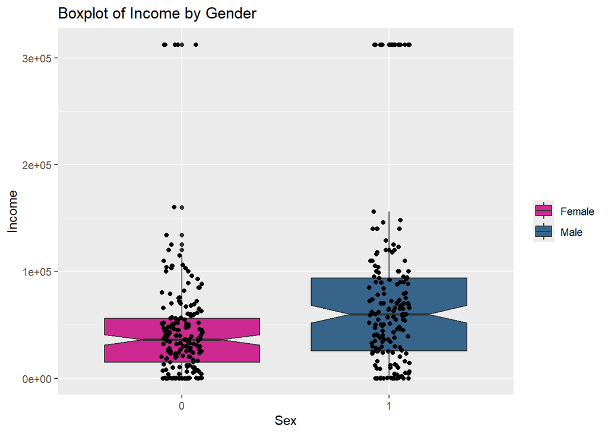

```r
# Examine in boxplot display
ggplot(nlsy_sub, aes( y = Self_Inc_2009, x = Sex))+
    geom_boxplot(aes(fill = Sex), notch = TRUE)+
    geom_jitter(aes(x = Sex), width = 0.1, color = "black") +
    ylab('Income') +
    scale_fill_manual(values=c("#CD2990","#36648B"),
                       name="", labels = c("Female","Male")) +
   ggtitle("Boxplot of Income by Gender")
```

```r
# Create subsets by gender to remove far out outliers
nlsy_subF <- nlsy_sub %>%
  filter(Sex == 0)  #females
# remove those beyond...
quantile(nlsy_subF$Self_Inc_2009)[4] + (IQR(nlsy_subF$Self_Inc_2009) * 3)
```

```
##    75%
## 180000
```

```r
# constitutes 'far out' outliers by Tukey's convention

nlsy_subM <- nlsy_sub %>%
  filter(Sex == 1)  #males
# remove those beyond...
quantile(nlsy_subM$Self_Inc_2009)[4] + (IQR(nlsy_subM$Self_Inc_2009) * 3)
```

```
##      75%
## 298449.2
```

```r
# constitutes 'far out' outliers by Tukey's convention

# Remove far out outliers
nlsy_sub_rm_outliers <- nlsy_sub %>%
  filter(Self_Inc_2009 > 0) %>%
  # safe cutoff for both to remove those 'far out' outliers since there aren't any in between 190k and 300k
  filter(Self_Inc_2009 < 200000)  %>%
  filter(Hghst_Deg_Obt != 0) # Remove the single individual with no degree

table(nlsy_sub_rm_outliers$Sex) # Number of males and females with outliers removed
```

```
##
##   0   1
## 158 142
```

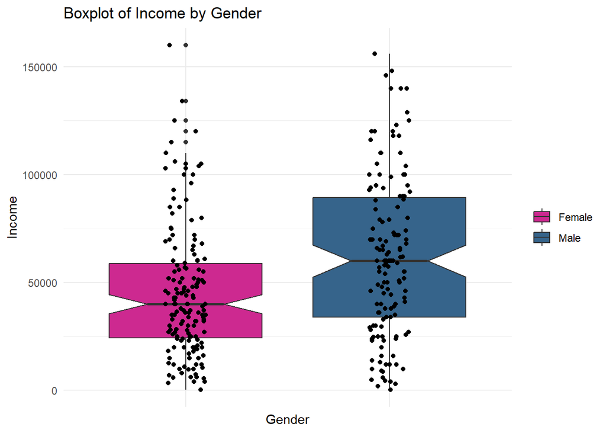

```r
# 0 = F, 1 = M

# Re-visualize boxplot with far out outliers removed
ggplot(nlsy_sub_rm_outliers, aes( y = Self_Inc_2009, x = Sex))+
    geom_boxplot(aes(fill = Sex), notch = TRUE)+
    geom_jitter(aes(x = Sex), width = 0.1, color = "black") +
    ylab('Income') +
    xlab('Gender') +
    scale_fill_manual(values=c("#CD2990","#36648B"),
                       name="", labels = c("Female","Male")) +
   ggtitle("Boxplot of Income by Gender") +
  theme_minimal() +
  theme(axis.text.x = element_blank())
```

## Visualize relationship between income and other variables, stratified by gender

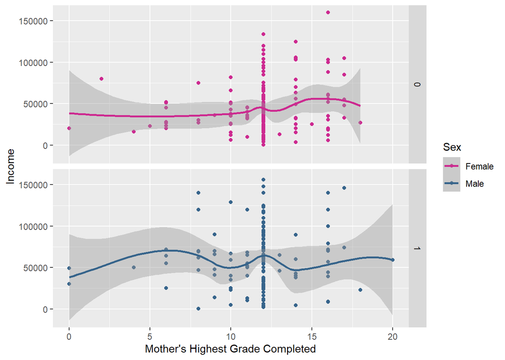

```r
# Income and highest grade completed by mother
ggplot(nlsy_sub_rm_outliers, aes(x = Hghst_Grde_Moth, y = Self_Inc_2009, group = Sex,
                                 color = Sex)) +
  geom_point() + # To call scatterplot
  geom_smooth(aes(color = Sex)) + # color smoothing lines by sex
  scale_color_manual(values = c("#CD2990", "#36648B"), labels = c("Female","Male")) +
  xlab("Mother's Highest Grade Completed") + # Label x-axis
  ylab("Income") +
  facet_grid(rows = vars(Sex))
```

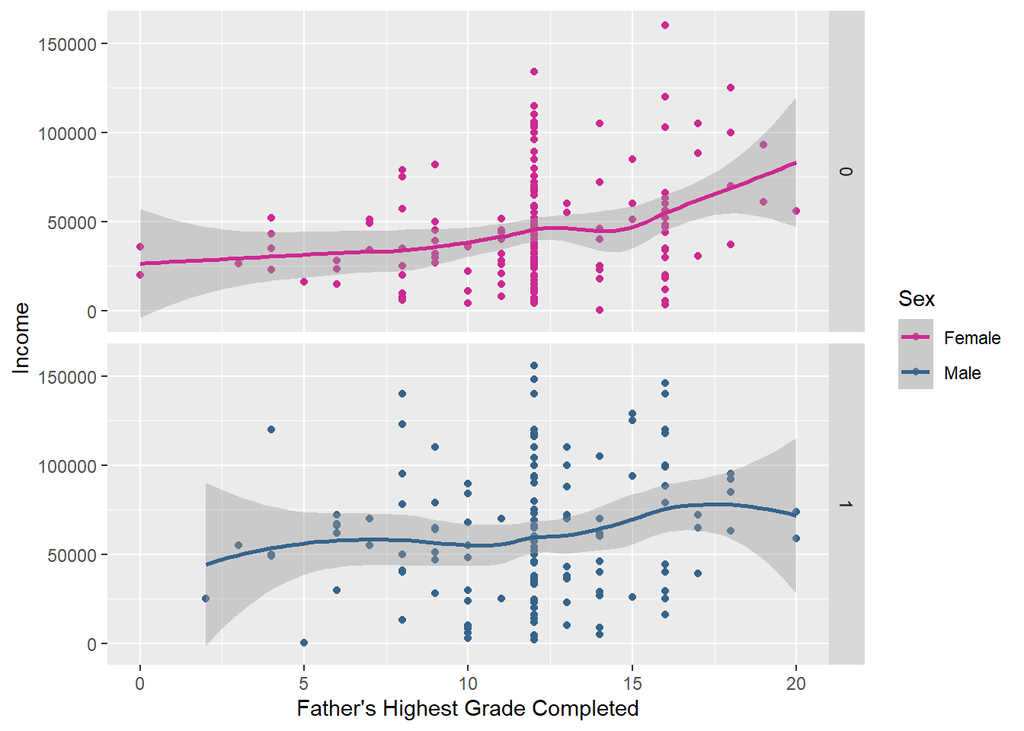

```r
# Income and highest grade completed by father
ggplot(nlsy_sub_rm_outliers, aes(x = Hghst_Grde_Fath, y = Self_Inc_2009, group = Sex,
                                 color = Sex)) +
  geom_point() + # To call scatterplot
  geom_smooth(aes(color = Sex)) + # color smoothing lines by sex
  scale_color_manual(values = c("#CD2990", "#36648B"), labels = c("Female","Male")) +
  xlab("Father's Highest Grade Completed") + # Label x-axis
  ylab("Income") +
  facet_grid(rows = vars(Sex))
```

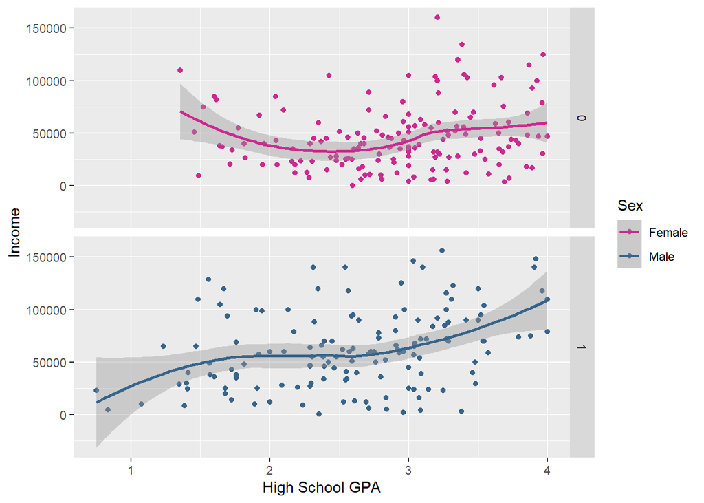

```r
# Income and GPA
ggplot(nlsy_sub_rm_outliers, aes(x = GPA, y = Self_Inc_2009, group = Sex,
                                 color = Sex)) +
  geom_point() + # To call scatterplot
  geom_smooth(aes(color = Sex)) + # color smoothing lines by sex
  scale_color_manual(values = c("#CD2990", "#36648B"), labels = c("Female","Male")) +
  xlab("High School GPA") + # Label x-axis
  ylab("Income") +
  facet_grid(rows = vars(Sex))
```

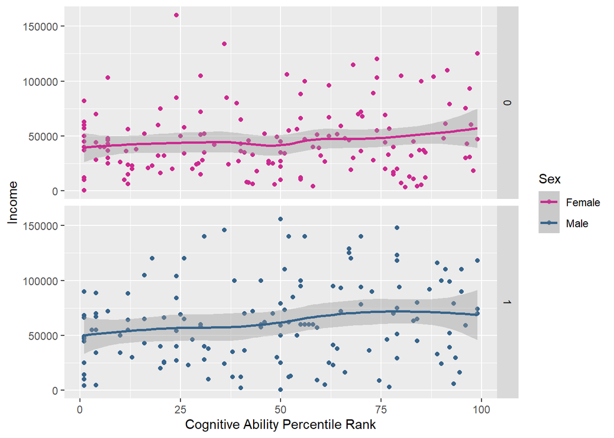

```r
# Income and Cognitive Ability Rank
ggplot(nlsy_sub_rm_outliers, aes(x = CogAbilityRank, y = Self_Inc_2009, group = Sex,
                                 color = Sex)) +
  geom_point() + # To call scatterplot
  geom_smooth(aes(color = Sex)) + # color smoothing lines by sex
  scale_color_manual(values = c("#CD2990", "#36648B"), labels = c("Female","Male")) +
  xlab("Cognitive Ability Percentile Rank") + # Label x-axis
  ylab("Income") +
  facet_grid(rows = vars(Sex))
```

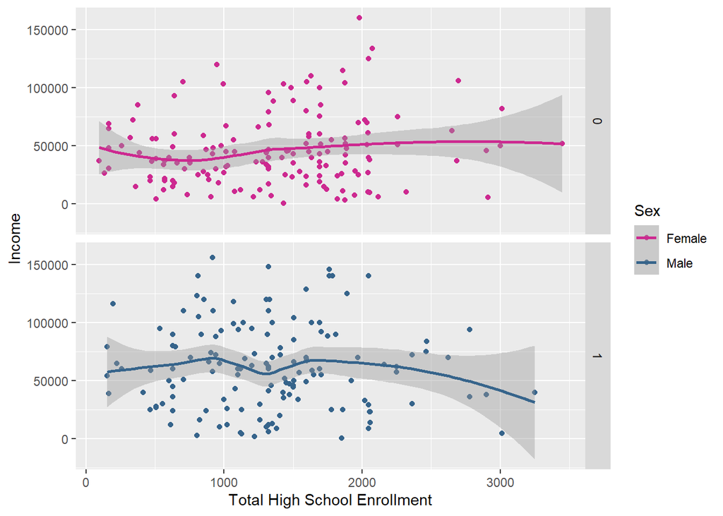

```r
# Income and Total Enrollment
ggplot(nlsy_sub_rm_outliers, aes(x = Total_Enrlmnt, y = Self_Inc_2009, group = Sex,
                                 color = Sex)) +
  geom_point() + # To call scatterplot
  geom_smooth(aes(color = Sex)) + # color smoothing lines by sex
  scale_color_manual(values = c("#CD2990", "#36648B"), labels = c("Female","Male")) +
  xlab("Total High School Enrollment") + # Label x-axis
  ylab("Income") +
  facet_grid(rows = vars(Sex))
```

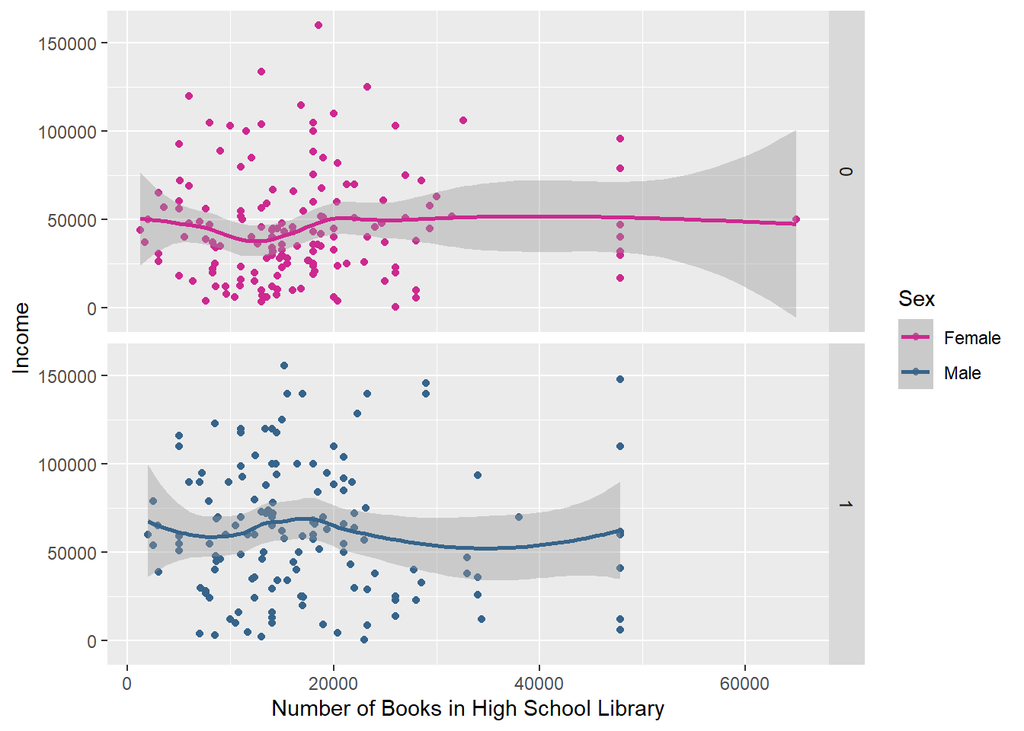

```r
# Income and Number of Books in School Lib.
ggplot(nlsy_sub_rm_outliers, aes(x = Num_Bks_Lib, y = Self_Inc_2009, group = Sex,
                                 color = Sex)) +
  geom_point() + # To call scatterplot
  geom_smooth(aes(color = Sex)) + # color smoothing lines by sex
  scale_color_manual(values = c("#CD2990", "#36648B"), labels = c("Female","Male")) +
  xlab("Number of Books in High School Library") + # Label x-axis
  ylab("Income") +
  facet_grid(rows = vars(Sex))
```

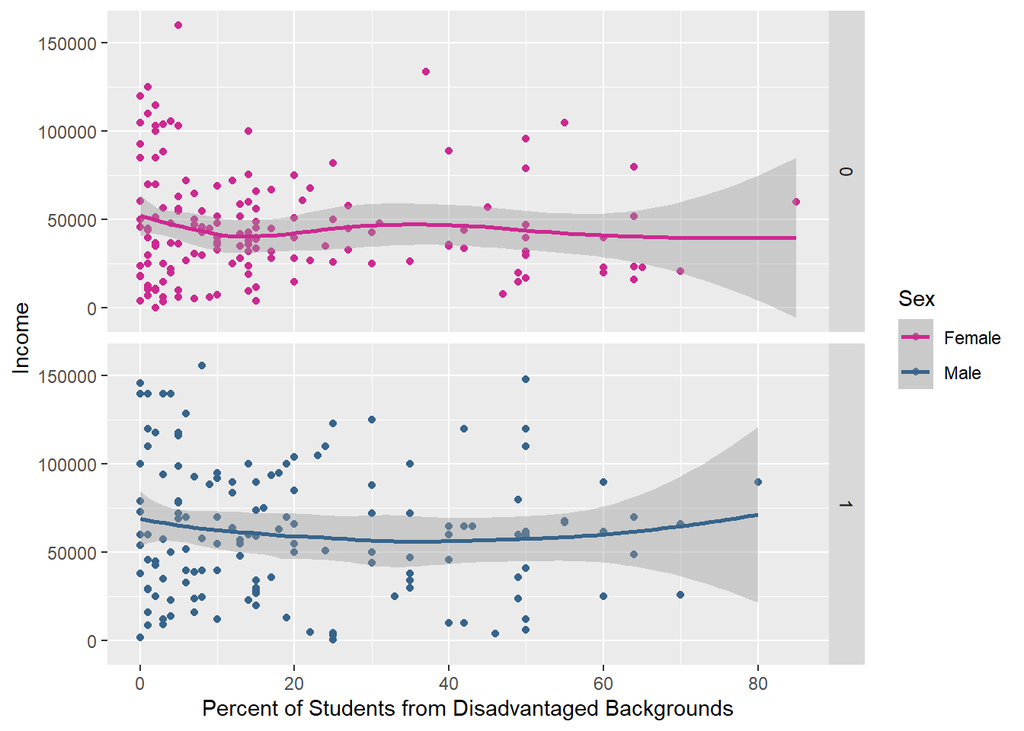

```r
# Income and Percent disadvantaged students at school
ggplot(nlsy_sub_rm_outliers, aes(x = Pct_Disadv, y = Self_Inc_2009, group = Sex,
                                 color = Sex)) +
  geom_point() + # To call scatterplot
  geom_smooth(aes(color = Sex)) + # color smoothing lines by sex
  scale_color_manual(values = c("#CD2990", "#36648B"), labels = c("Female","Male")) +
  xlab("Percent of Students from Disadvantaged Backgrounds") + # Label x-axis
  ylab("Income") +
  facet_grid(rows = vars(Sex))
```

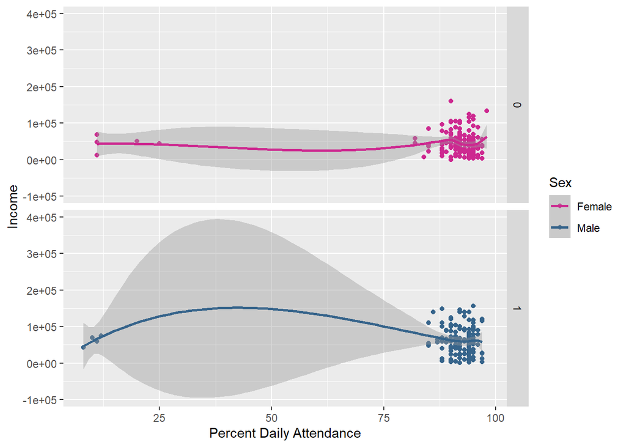

```r
# Income and HS percent daily attendance
ggplot(nlsy_sub_rm_outliers, aes(x = Pct_Attnd, y = Self_Inc_2009, group = Sex,
                                 color = Sex)) +
  geom_point() + # To call scatterplot
  geom_smooth(aes(color = Sex)) + # color smoothing lines by sex
  scale_color_manual(values = c("#CD2990", "#36648B"), labels = c("Female","Male")) +
  xlab("Percent Daily Attendance") + # Label x-axis
  ylab("Income") +
  facet_grid(rows = vars(Sex))
```

```r
# Will remove later on given minimal variance and far out outliers in the percent of daily attendance
```

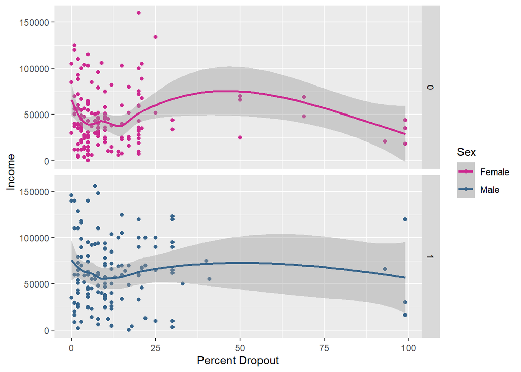

```r
# Income and HS percent dropout
ggplot(nlsy_sub_rm_outliers, aes(x = Pct_Dropout, y = Self_Inc_2009, group = Sex,
                                 color = Sex)) +
  geom_point() + # To call scatterplot
  geom_smooth(aes(color = Sex)) + # color smoothing lines by sex
  scale_color_manual(values = c("#CD2990", "#36648B"), labels = c("Female","Male")) +
  xlab("Percent Dropout") + # Label x-axis
  ylab("Income") +
  facet_grid(rows = vars(Sex))
```

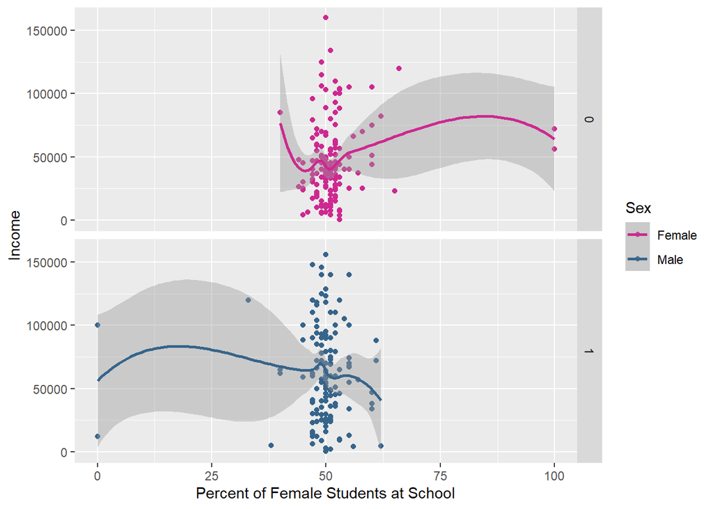

```r
# Income and HS percent female students
ggplot(nlsy_sub_rm_outliers, aes(x = Pct_Stdnt_Female, y = Self_Inc_2009, group = Sex,
                                 color = Sex)) +
  geom_point() + # To call scatterplot
  geom_smooth(aes(color = Sex)) + # color smoothing lines by sex
  scale_color_manual(values = c("#CD2990", "#36648B"), labels = c("Female","Male")) +
  xlab("Percent of Female Students at School") + # Label x-axis
  ylab("Income") +
  facet_grid(rows = vars(Sex))
```

```r
# Will remove later on based on the minimal information in this variable
```

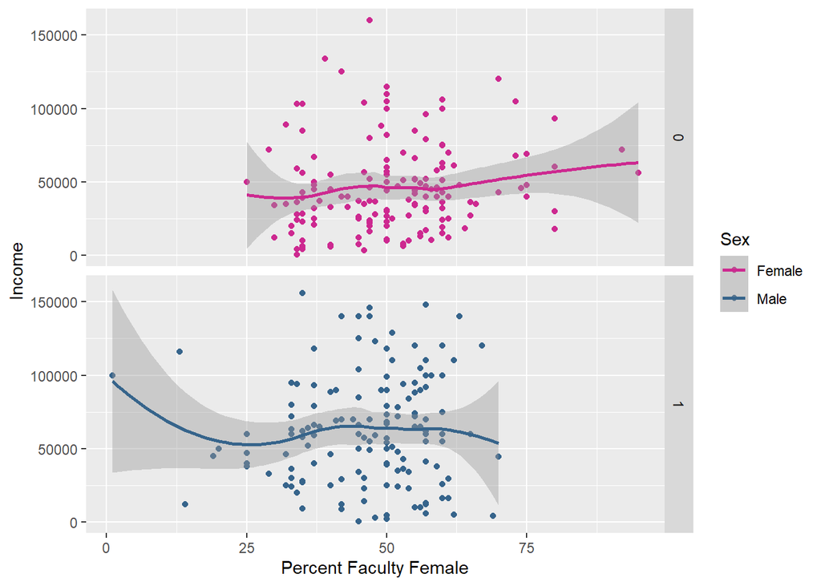

```r
# Income and HS percent faculty female
ggplot(nlsy_sub_rm_outliers, aes(x = Pct_Fac_Female, y = Self_Inc_2009, group = Sex,
                                 color = Sex)) +
  geom_point() + # To call scatterplot
  geom_smooth(aes(color = Sex)) + # color smoothing lines by sex
  scale_color_manual(values = c("#CD2990", "#36648B"), labels = c("Female","Male")) +
  xlab("Percent Faculty Female") + # Label x-axis
  ylab("Income") +
  facet_grid(rows = vars(Sex))
```

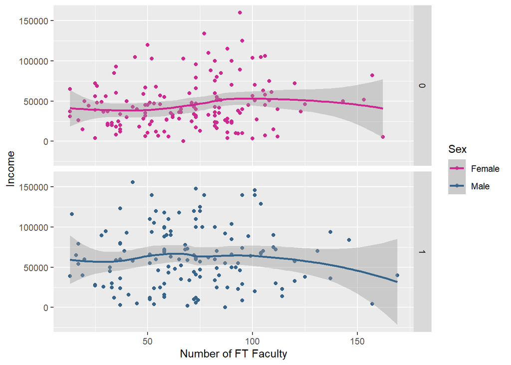

```r
# Income and number FT faculty
ggplot(nlsy_sub_rm_outliers, aes(x = Num_FT_Fac, y = Self_Inc_2009, group = Sex,
                                 color = Sex)) +
  geom_point() + # To call scatterplot
  geom_smooth(aes(color = Sex)) + # color smoothing lines by sex
  scale_color_manual(values = c("#CD2990", "#36648B"), labels = c("Female","Male")) +
  xlab("Number of FT Faculty") + # Label x-axis
  ylab("Income") +
  facet_grid(rows = vars(Sex))
```

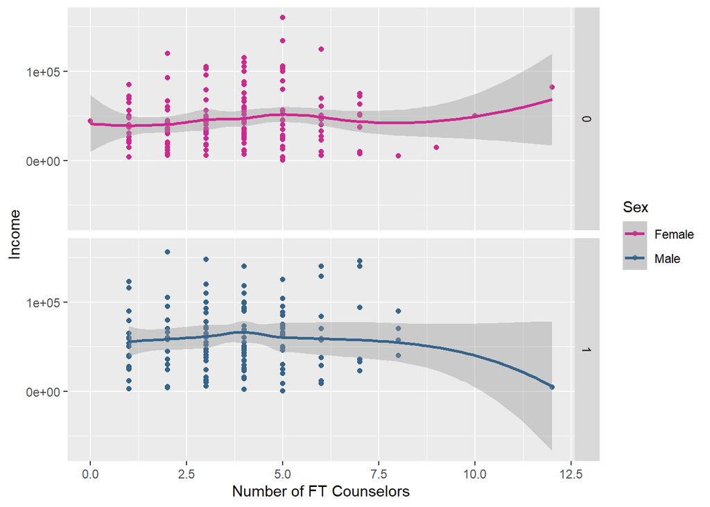

```r
# Income and HS number FT counselors
ggplot(nlsy_sub_rm_outliers, aes(x = Num_FT_Couns, y = Self_Inc_2009, group = Sex,
                                 color = Sex)) +
  geom_point() + # To call scatterplot
  geom_smooth(aes(color = Sex)) + # color smoothing lines by sex
  scale_color_manual(values = c("#CD2990", "#36648B"), labels = c("Female","Male")) +
  xlab("Number of FT Counselors") + # Label x-axis
  ylab("Income") +
  facet_grid(rows = vars(Sex))
```

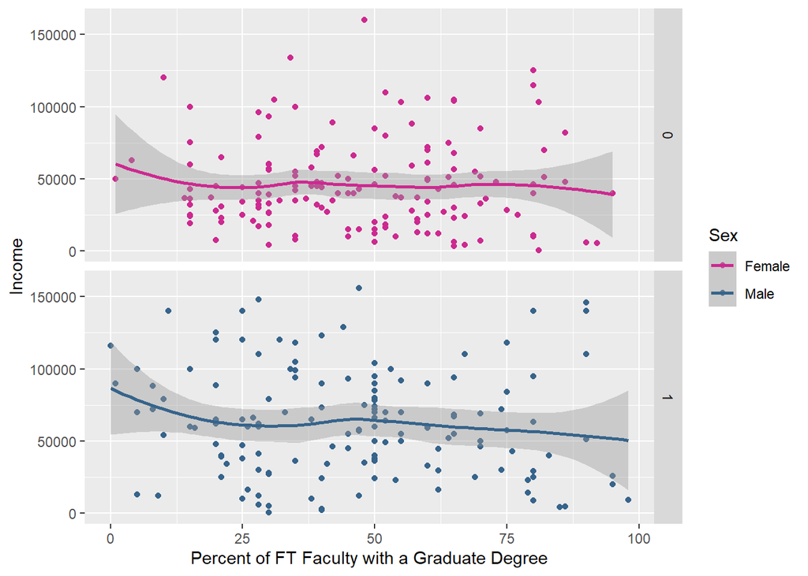

```r
# Income and pct ft faculty with grad degree
ggplot(nlsy_sub_rm_outliers, aes(x = Pct_FT_Fac_GrdDeg, y = Self_Inc_2009, group = Sex,
                                 color = Sex)) +
  geom_point() + # To call scatterplot
  geom_smooth(aes(color = Sex)) + # color smoothing lines by sex
  scale_color_manual(values = c("#CD2990", "#36648B"), labels = c("Female","Male")) +
  xlab("Percent of FT Faculty with a Graduate Degree") + # Label x-axis
  ylab("Income") +
  facet_grid(rows = vars(Sex))
```

```
## Notch went outside hinges
## ℹ Do you want `notch = FALSE`?
```

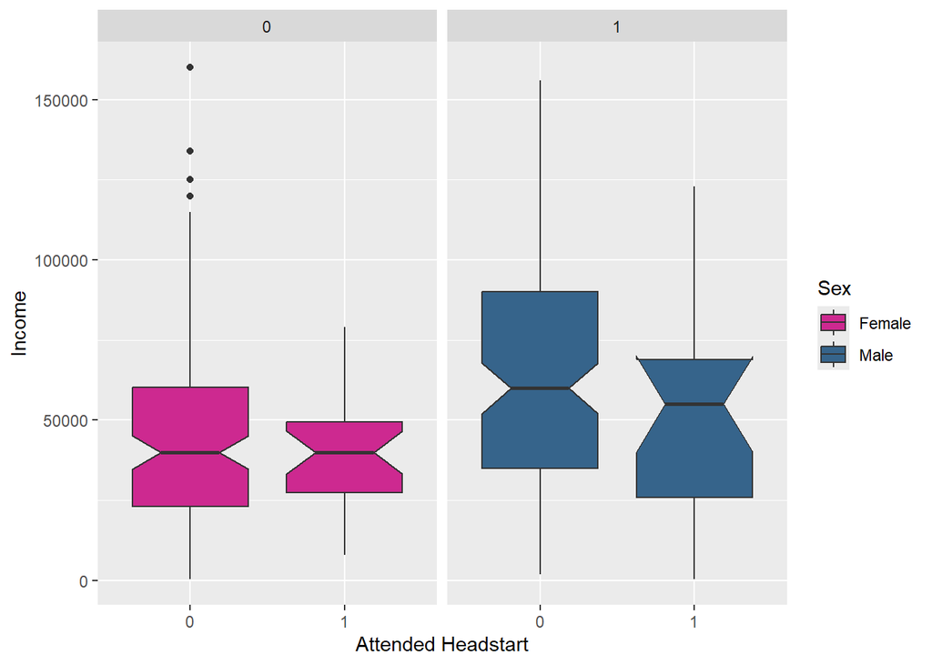

```r
ggplot(nlsy_sub_rm_outliers, aes(x = Headstart, y = Self_Inc_2009, group = Headstart,
                                 fill = Sex)) +
  geom_boxplot(notch = TRUE) +
  scale_fill_manual(values = c("#CD2990", "#36648B"), labels = c("Female","Male")) +
  xlab("Attended Headstart") + # Label x-axis
  ylab("Income") +
  facet_grid(cols = vars(Sex))
```

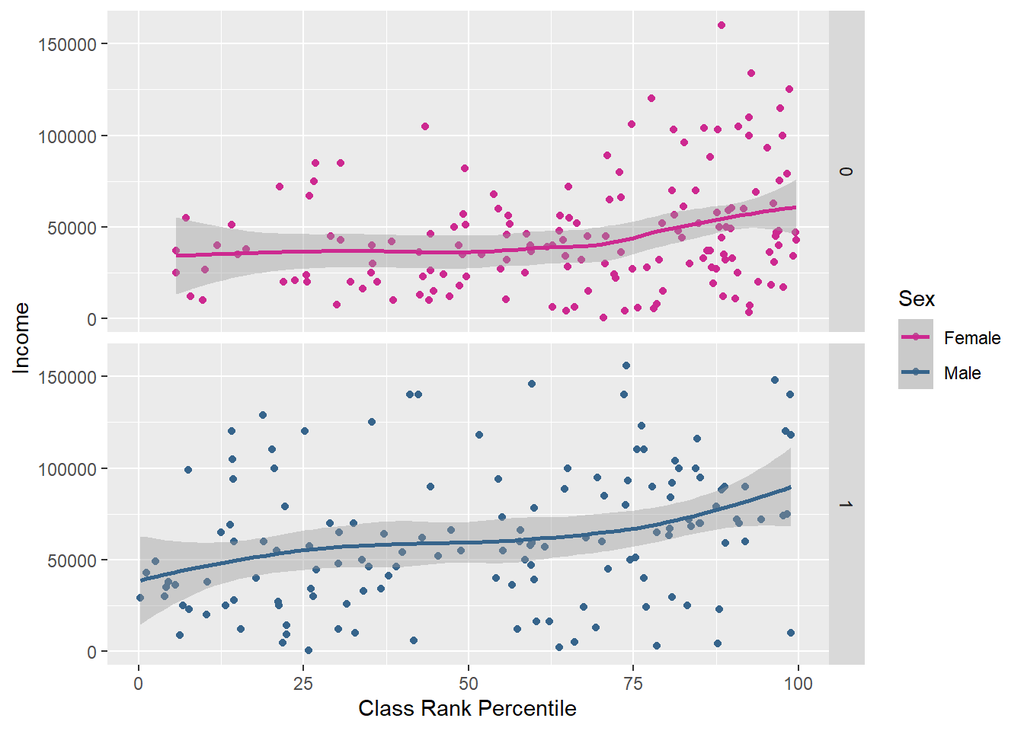

```r
# Income and Class Rank percentile
ggplot(nlsy_sub_rm_outliers, aes(x = ClassRankPercentile, y = Self_Inc_2009, group = Sex,
                                 color = Sex)) +
  geom_point() + # To call scatterplot
  geom_smooth(aes(color = Sex)) + # color smoothing lines by sex
  scale_color_manual(values = c("#CD2990", "#36648B"), labels = c("Female","Male")) +
  xlab("Class Rank Percentile") + # Label x-axis
  ylab("Income") +
  facet_grid(rows = vars(Sex))
```

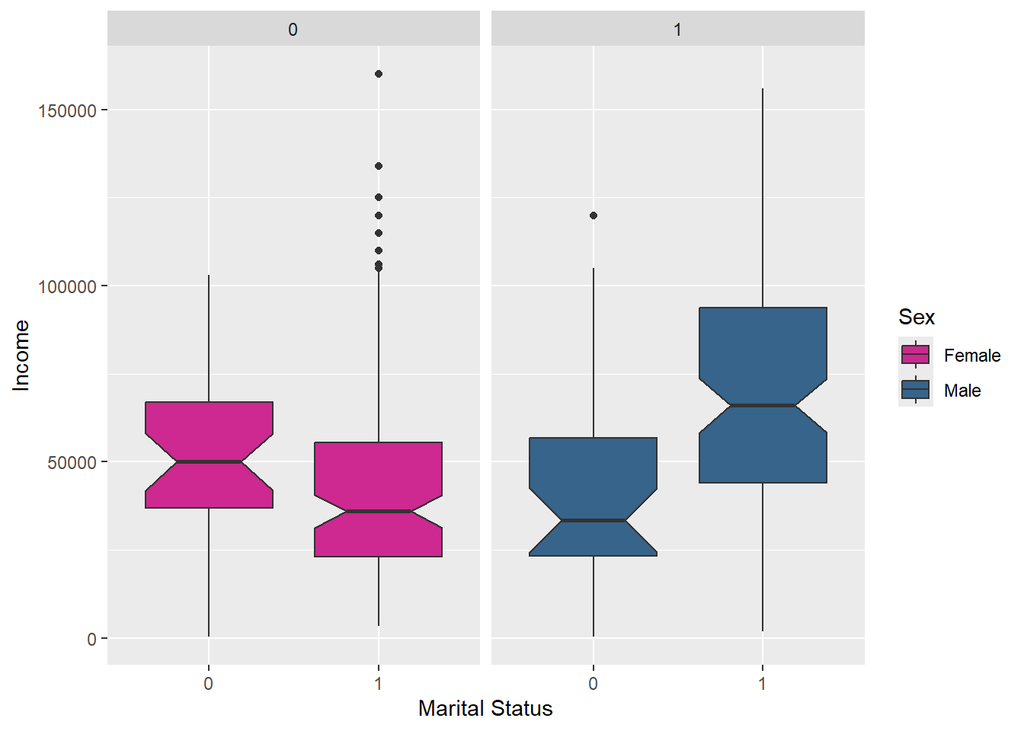

```r
# Income and marital status
ggplot(nlsy_sub_rm_outliers, aes(x = Marital_Status, y = Self_Inc_2009, group = Marital_Status,
                                 fill = Sex)) +
  geom_boxplot(notch = TRUE) +
  scale_fill_manual(values = c("#CD2990", "#36648B"), labels = c("Female","Male")) +
  xlab("Marital Status") + # Label x-axis
  ylab("Income") +
  facet_grid(cols = vars(Sex))
```

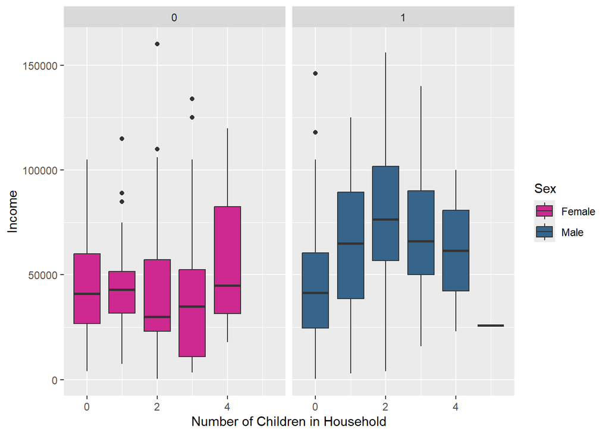

```r
# Income and number of kids
ggplot(nlsy_sub_rm_outliers, aes(x = Num_Kids_HH, y = Self_Inc_2009, group = Num_Kids_HH,
                                 fill = Sex)) +
  geom_boxplot() +
  scale_fill_manual(values = c("#CD2990", "#36648B"), labels = c("Female","Male")) +
  xlab("Number of Children in Household") + # Label x-axis
  ylab("Income") +
  facet_grid(cols = vars(Sex))
```

[output not shown]

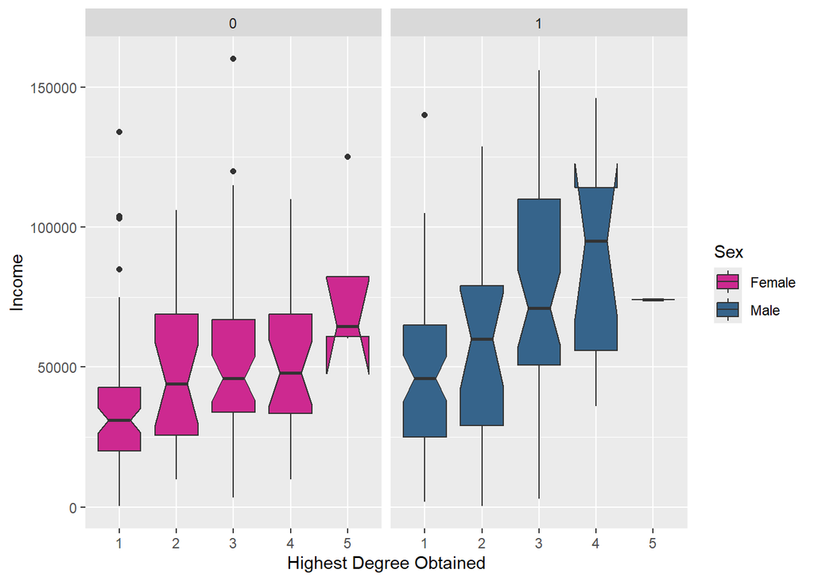

```r
# Income and highest degree obtained
ggplot(nlsy_sub_rm_outliers, aes(x = Hghst_Deg_Obt, y = Self_Inc_2009, group = Hghst_Deg_Obt,
                                 fill = Sex)) +
  geom_boxplot(notch = TRUE) +
  scale_fill_manual(values = c("#CD2990", "#36648B"), labels = c("Female","Male")) +
  xlab("Highest Degree Obtained") + # Label x-axis
  ylab("Income") +
  facet_grid(cols = vars(Sex))
```

# 3 PCA

To reduce the number of variable input in the regression, will conduct a PCA on the individual and school-level variables related to education.

## 3.1 STEP 1: Correlations for strong multicollinearity

- Look for correlations > .90

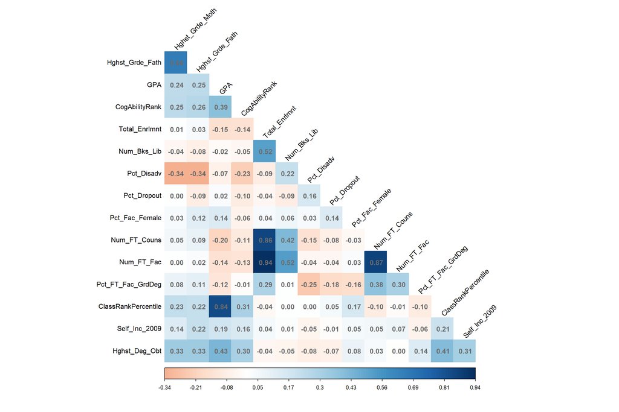

```r
nlsy_sub_num <- nlsy_sub_rm_outliers %>%
  # Filter out non-numeric variables (binary indicators), and variables not included in the analysis or PCA
  dplyr::select(-c(Sex, Headstart,Marital_Status, Pct_Stdnt_Female, Pct_Attnd, Num_Kids_HH)) %>%
  mutate(Hghst_Deg_Obt = as.numeric(Hghst_Deg_Obt))

corrplot(cor(nlsy_sub_num),
         type="lower", #put color strength on bottom
         tl.pos = "ld", #Character or logical, position of text labels,
         #'ld'(default if type=='lower') means left and diagonal,
         tl.cex = 1, #Numeric, for the size of text label (variable names).
         method="color",
         addCoef.col="gray42",
         diag=FALSE,
         tl.col="black", #The color of text label.
         tl.srt=45, #Numeric, for text label string rotation in degrees, see text
         is.corr = FALSE, #if you include correlation matrix
         #order = "hclust", #order results by strength
         #col=gray.colors(100), #in case you want it in gray...
         number.digits = 2) #number of digits after decimal
```

Number of FT faculty is redundant with total enrollment. Will remove number of FT faculty. Also removing percent daily attendance and percent of students who are female from notes earlier.

```r
nlsy_sub_rm_outliers <- nlsy_sub_rm_outliers %>%
  dplyr::select(-Num_FT_Fac, -Pct_Stdnt_Female, -Pct_Attnd)
```

## 3.2 STEP 2: Scale the variables

```r
glimpse(nlsy_sub_rm_outliers)
```

```
## Rows: 300
## Columns: 18
## $ Sex                 <fct> 0, 1, 1, 1, 1, 0, 0, 0, 0, 0, 1, 1, 1, 0, 0, 0, 1,…
## $ Hghst_Grde_Moth     <int> 12, 12, 17, 12, 11, 14, 12, 12, 14, 10, 12, 12, 12…
## $ Hghst_Grde_Fath     <int> 12, 12, 16, 9, 9, 16, 16, 12, 12, 8, 18, 8, 12, 14…
## $ GPA                 <dbl> 2.655172, 2.541667, 3.033333, 3.307692, 2.593750, …
## $ CogAbilityRank      <dbl> 78.00, 70.00, 36.00, 91.00, 79.00, 81.00, 77.00, 8…
## $ Total_Enrlmnt       <int> 1634, 1761, 1761, 706, 706, 1874, 1874, 1874, 1027…
## $ Num_Bks_Lib         <int> 20000, 29000, 29000, 5000, 5000, 13000, 13000, 130…
## $ Pct_Disadv          <int> 10, 0, 0, 24, 24, 3, 3, 3, 10, 9, 18, 18, 15, 12, …
## $ Pct_Dropout         <int> 2, 0, 0, 2, 2, 4, 4, 4, 10, 14, 5, 5, 1, 2, 4, 5, …
## $ Pct_Fac_Female      <int> 43, 47, 47, 51, 51, 46, 46, 46, 40, 40, 33, 33, 34…
## $ Num_FT_Couns        <int> 5, 7, 7, 4, 4, 5, 5, 5, 3, 6, 5, 5, 5, 1, 5, 3, 4,…
## $ Pct_FT_Fac_GrdDeg   <int> 46, 90, 90, 90, 90, 65, 65, 65, 70, 90, 80, 80, 95…
## $ Headstart           <fct> 0, 0, 0, 0, 0, 0, 0, 0, 0, 0, 0, 0, 0, 1, 0, 0, 0,…
## $ ClassRankPercentile <dbl> 62.69430, 42.40964, 59.59596, 75.57604, 75.29412, …
## $ Marital_Status      <fct> 1, 1, 1, 1, 1, 1, 0, 1, 1, 1, 1, 1, 1, 0, 1, 1, 1,…
## $ Num_Kids_HH         <int> 0, 2, 0, 1, 0, 3, 0, 0, 3, 3, 1, 2, 0, 2, 1, 0, 2,…
## $ Self_Inc_2009       <int> 40000, 140000, 146000, 110000, 51000, 3500, 56500,…
## $ Hghst_Deg_Obt       <fct> 3, 3, 4, 3, 3, 3, 3, 1, 2, 1, 2, 2, 1, 2, 1, 1, 3,…
```

```r
# remove income because that's what I want to predict and sex because I want to predict for males and females separately, also remove marital status and headstart because binary, and number of kids because logically does not relate to anything
nlsy_sub_pred <- nlsy_sub_rm_outliers %>%
  dplyr::select(-Self_Inc_2009, -Sex, -Marital_Status, -Headstart, -Num_Kids_HH) %>%
  mutate(Hghst_Deg_Obt = as.numeric(Hghst_Deg_Obt))

dim(nlsy_sub_pred)
```

```
## [1] 300  13
```

```r
scaled_data_pca <- nlsy_sub_pred %>%
  mutate_at(c(1:13), ~(scale(.) %>% as.vector))

psych::describe(scaled_data_pca)
```

```
##                     vars   n mean sd median trimmed  mad   min  max range  skew
## Hghst_Grde_Moth        1 300    0  1   0.06    0.06 0.00 -4.23 2.93  7.16 -0.98
## Hghst_Grde_Fath        2 300    0  1   0.04    0.06 0.86 -3.44 2.36  5.80 -0.59
## GPA                    3 300    0  1   0.11    0.04 0.98 -2.92 1.79  4.71 -0.38
## CogAbilityRank         4 300    0  1   0.09   -0.01 1.29 -1.55 1.73  3.27 -0.01
## Total_Enrlmnt          5 300    0  1  -0.02   -0.04 0.99 -1.93 3.29  5.22  0.40
## Num_Bks_Lib            6 300    0  1  -0.21   -0.13 0.71 -1.58 4.69  6.27  1.52
## Pct_Disadv             7 300    0  1  -0.33   -0.14 0.76 -0.99 3.37  4.36  1.11
## Pct_Dropout            8 300    0  1  -0.29   -0.20 0.43 -0.75 4.99  5.74  3.46
## Pct_Fac_Female         9 300    0  1   0.10   -0.01 0.95 -3.81 3.69  7.50  0.04
## Num_FT_Couns          10 300    0  1   0.10   -0.06 0.78 -2.00 4.30  6.29  0.75
## Pct_FT_Fac_GrdDeg     11 300    0  1   0.02   -0.02 1.11 -2.10 2.36  4.46  0.19
## ClassRankPercentile   12 300    0  1   0.17    0.05 1.20 -2.08 1.44  3.52 -0.38
## Hghst_Deg_Obt         13 300    0  1  -0.14   -0.09 1.30 -1.01 2.48  3.50  0.41
##                     kurtosis   se
## Hghst_Grde_Moth         3.39 0.06
## Hghst_Grde_Fath         1.12 0.06
## GPA                    -0.43 0.06
## CogAbilityRank         -1.20 0.06
## Total_Enrlmnt           0.10 0.06
## Num_Bks_Lib             3.12 0.06
## Pct_Disadv              0.21 0.06
## Pct_Dropout            13.53 0.06
## Pct_Fac_Female          1.17 0.06
## Num_FT_Couns            1.54 0.06
## Pct_FT_Fac_GrdDeg      -0.70 0.06
## ClassRankPercentile    -1.08 0.06
## Hghst_Deg_Obt          -1.07 0.06
```

## 3.3 STEP 3: Visualizing PCA

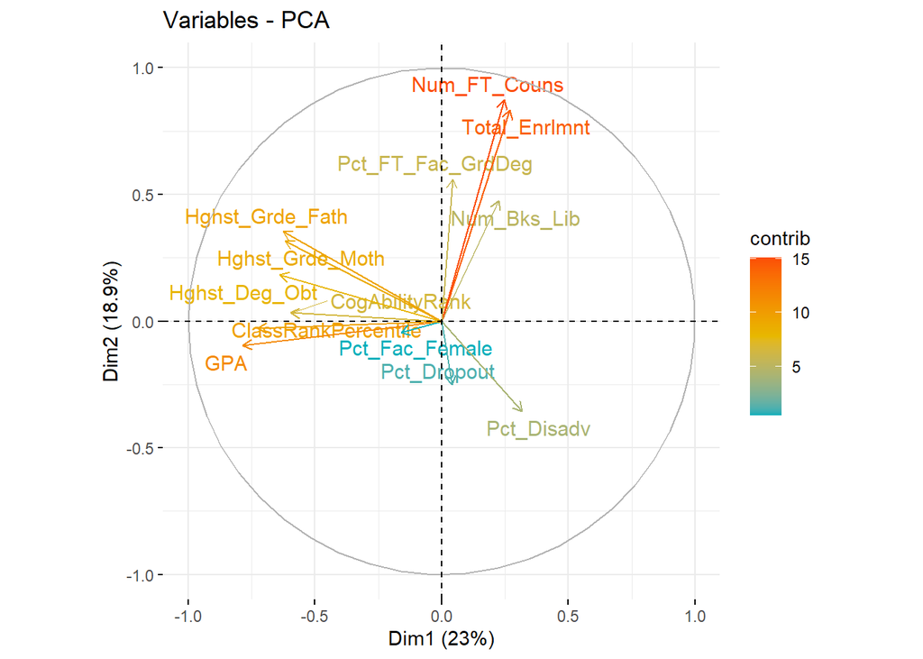

```r
#line below runs a simple PCA with a component for each variable.
#the most variance will be explained in component 1 and 2
viz_pca <- prcomp(scaled_data_pca, center = TRUE,scale. = TRUE)


#Graph of variables. Positive correlated variables point to the same side of the plot. Negative correlated variables point to opposite sides of the graph.

fviz_pca_var(viz_pca,
             col.var = "contrib", # Color by contributions to the PC
             gradient.cols = c("#00AFBB", "#E7B800", "#FC4E07"),
             repel = TRUE #Avoid overlapping text if possible
             )
```

## 3.4 STEP 4: Bartlett’s test

```r
cortest.bartlett(scaled_data_pca, 300) #300 equals sample size
```

```
## R was not square, finding R from data
```

```
## $chisq
## [1] 1474.779
##
## $p.value
## [1] 1.078438e-256
##
## $df
## [1] 78
```

```r
# p value below .05, so it is not an identity matrix
```

## 3.5 STEP 5: KMO

Measure of Sampling Adequacy (MSA) of factor analytic data matrices called the Kaiser-Meyer-Olkin (KMO) index.

The test measures sampling adequacy for each variable in the model and for the complete model.

The statistic is a measure of the proportion of variance among variables that might be common variance.

The higher the proportion, the more suited your data is to Factor Analysis.

- Kaiser (1974) recommends a bare minimum of .5
- values between .5 and .7 are mediocre
- values between .7 and .8 are good
- values between .8 and .9 are great
- values above .9 are superb

```r
KMO(scaled_data_pca)
```

```
## Kaiser-Meyer-Olkin factor adequacy
## Call: KMO(r = scaled_data_pca)
## Overall MSA =  0.65
## MSA for each item =
##     Hghst_Grde_Moth     Hghst_Grde_Fath                 GPA      CogAbilityRank
##                0.66                0.69                0.63                0.83
##       Total_Enrlmnt         Num_Bks_Lib          Pct_Disadv         Pct_Dropout
##                0.59                0.61                0.59                0.49
##      Pct_Fac_Female        Num_FT_Couns   Pct_FT_Fac_GrdDeg ClassRankPercentile
##                0.53                0.63                0.76                0.61
##       Hghst_Deg_Obt
##                0.80
```

```r
scaled_data_pca <- scaled_data_pca %>%
  dplyr::select(-Pct_Dropout) # small KMO

KMO(scaled_data_pca)
```

```
## Kaiser-Meyer-Olkin factor adequacy
## Call: KMO(r = scaled_data_pca)
## Overall MSA =  0.65
## MSA for each item =
##     Hghst_Grde_Moth     Hghst_Grde_Fath                 GPA      CogAbilityRank
##                0.68                0.70                0.63                0.82
##       Total_Enrlmnt         Num_Bks_Lib          Pct_Disadv      Pct_Fac_Female
##                0.59                0.65                0.60                0.53
##        Num_FT_Couns   Pct_FT_Fac_GrdDeg ClassRankPercentile       Hghst_Deg_Obt
##                0.62                0.75                0.61                0.81
```

```r
scaled_data_pca <- scaled_data_pca %>%
   dplyr::select(-Pct_Fac_Female) # logically doesn't fit with anything and low KMO

KMO(scaled_data_pca)
```

```
## Kaiser-Meyer-Olkin factor adequacy
## Call: KMO(r = scaled_data_pca)
## Overall MSA =  0.66
## MSA for each item =
##     Hghst_Grde_Moth     Hghst_Grde_Fath                 GPA      CogAbilityRank
##                0.69                0.71                0.63                0.84
##       Total_Enrlmnt         Num_Bks_Lib          Pct_Disadv        Num_FT_Couns
##                0.59                0.65                0.60                0.62
##   Pct_FT_Fac_GrdDeg ClassRankPercentile       Hghst_Deg_Obt
##                0.77                0.61                0.82
```

## 3.6 STEP 6: Baseline PCA to select number of components

```r
#run a base pca with as many components as possible
pca_base <- principal(scaled_data_pca, nfactors = 11, rotate = "none")

pca_base #results
```

```
## Principal Components Analysis
## Call: principal(r = scaled_data_pca, nfactors = 11, rotate = "none")
## Standardized loadings (pattern matrix) based upon correlation matrix
##                       PC1   PC2   PC3   PC4   PC5   PC6   PC7   PC8   PC9  PC10
## Hghst_Grde_Moth      0.62  0.33 -0.32  0.44  0.17  0.00  0.13 -0.08  0.39  0.02
## Hghst_Grde_Fath      0.62  0.35 -0.33  0.39  0.17 -0.01  0.09  0.21 -0.38 -0.01
## GPA                  0.78 -0.08  0.46 -0.15 -0.08 -0.24  0.10 -0.04 -0.04  0.26
## CogAbilityRank       0.60  0.02  0.01 -0.10 -0.55  0.53  0.02  0.20  0.06 -0.02
## Total_Enrlmnt       -0.28  0.85  0.25  0.02 -0.09 -0.13 -0.14  0.14  0.05 -0.05
## Num_Bks_Lib         -0.24  0.49  0.58  0.32 -0.12  0.24  0.23 -0.37 -0.12 -0.03
## Pct_Disadv          -0.32 -0.33  0.59  0.14  0.44  0.29  0.15  0.33  0.07  0.04
## Num_FT_Couns        -0.26  0.88  0.12 -0.05 -0.03 -0.06 -0.19  0.18  0.06  0.11
## Pct_FT_Fac_GrdDeg   -0.04  0.54 -0.31 -0.60  0.23  0.11  0.43 -0.02 -0.01 -0.01
## ClassRankPercentile  0.72  0.00  0.53 -0.15  0.00 -0.32  0.09  0.08  0.05 -0.23
## Hghst_Deg_Obt        0.64  0.19  0.13 -0.23  0.42  0.32 -0.41 -0.19 -0.04 -0.02
##                      PC11 h2       u2 com
## Hghst_Grde_Moth      0.01  1  1.1e-16 4.3
## Hghst_Grde_Fath      0.00  1 -4.4e-16 4.5
## GPA                  0.06  1  2.1e-15 2.4
## CogAbilityRank       0.01  1  3.3e-16 3.3
## Total_Enrlmnt        0.25  1  1.7e-15 1.8
## Num_Bks_Lib         -0.04  1  1.1e-16 4.9
## Pct_Disadv           0.01  1  0.0e+00 4.9
## Num_FT_Couns        -0.22  1  6.7e-16 1.6
## Pct_FT_Fac_GrdDeg    0.01  1  2.2e-16 3.8
## ClassRankPercentile -0.09  1  1.0e-15 2.8
## Hghst_Deg_Obt        0.02  1  1.1e-16 4.2
##
##                        PC1  PC2  PC3  PC4  PC5  PC6  PC7  PC8  PC9 PC10 PC11
## SS loadings           2.97 2.42 1.58 0.95 0.81 0.72 0.53 0.43 0.33 0.14 0.12
## Proportion Var        0.27 0.22 0.14 0.09 0.07 0.07 0.05 0.04 0.03 0.01 0.01
## Cumulative Var        0.27 0.49 0.63 0.72 0.79 0.86 0.91 0.95 0.98 0.99 1.00
## Proportion Explained  0.27 0.22 0.14 0.09 0.07 0.07 0.05 0.04 0.03 0.01 0.01
## Cumulative Proportion 0.27 0.49 0.63 0.72 0.79 0.86 0.91 0.95 0.98 0.99 1.00
##
## Mean item complexity =  3.5
## Test of the hypothesis that 11 components are sufficient.
##
## The root mean square of the residuals (RMSR) is  0
##  with the empirical chi square  0  with prob <  NA
##
## Fit based upon off diagonal values = 1
```

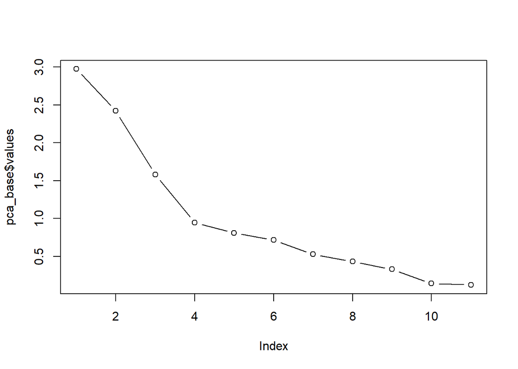

```r
# Kaiser's rule (eigenvalues >= 1.0) would tell us 3

#scree plot
plot(pca_base$values, type = "b")
```

```r
# Scree plot suggests 3 components as well
```

## 3.7 STEP 7: Check that residuals are normally distributed

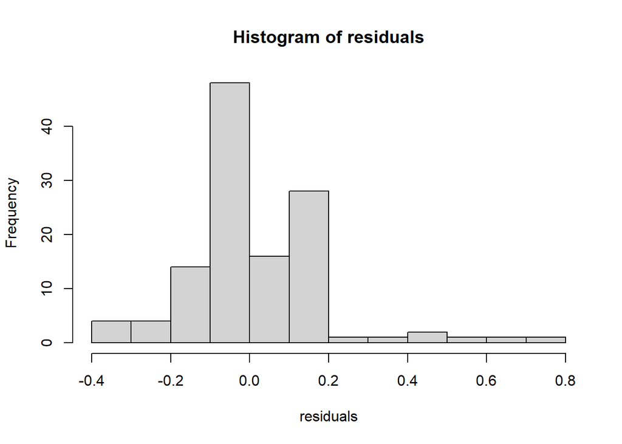

```r
pca_resid <- principal(scaled_data_pca, nfactors = 3, rotate = "promax")

#residuals
#require correlation matrix for final data
corMatrix<-cor(scaled_data_pca)
#corMatrix

#next,create an object from the correlation matrix and the pca loading. Call it residuals. It will contain the factor residuals
residuals<-factor.residuals(corMatrix, pca_resid$loadings)

#call a histogram to check residuals
hist(residuals) # Looks pretty good, positively skewed, but not bad
```

## 3.8 STEP 8: Informed PCA with specific number of components

```r
#rotation. Since factors should be related, use oblique technique (promax), if unrelated, use varimax
pca_final <- principal(scaled_data_pca, nfactors = 3, rotate = "promax")
pca_final #results.
```

```
## Principal Components Analysis
## Call: principal(r = scaled_data_pca, nfactors = 3, rotate = "promax")
## Standardized loadings (pattern matrix) based upon correlation matrix
##                       RC1   RC2   RC3   h2   u2 com
## Hghst_Grde_Moth      0.19  0.01  0.70 0.59 0.41 1.2
## Hghst_Grde_Fath      0.18  0.03  0.72 0.62 0.38 1.1
## GPA                  0.91 -0.06 -0.04 0.83 0.17 1.0
## CogAbilityRank       0.44 -0.12  0.29 0.37 0.63 1.9
## Total_Enrlmnt       -0.02  0.93  0.02 0.87 0.13 1.0
## Num_Bks_Lib          0.27  0.73 -0.38 0.63 0.37 1.8
## Pct_Disadv           0.23  0.03 -0.78 0.57 0.43 1.2
## Num_FT_Couns        -0.10  0.89  0.16 0.86 0.14 1.1
## Pct_FT_Fac_GrdDeg   -0.27  0.36  0.47 0.39 0.61 2.5
## ClassRankPercentile  0.92  0.05 -0.09 0.80 0.20 1.0
## Hghst_Deg_Obt        0.55  0.07  0.28 0.46 0.54 1.5
##
##                        RC1  RC2  RC3
## SS loadings           2.44 2.36 2.18
## Proportion Var        0.22 0.21 0.20
## Cumulative Var        0.22 0.44 0.63
## Proportion Explained  0.35 0.34 0.31
## Cumulative Proportion 0.35 0.69 1.00
##
##  With component correlations of
##       RC1   RC2  RC3
## RC1  1.00 -0.12 0.26
## RC2 -0.12  1.00 0.04
## RC3  0.26  0.04 1.00
##
## Mean item complexity =  1.4
## Test of the hypothesis that 3 components are sufficient.
##
## The root mean square of the residuals (RMSR) is  0.09
##  with the empirical chi square  257.35  with prob <  1.9e-40
##
## Fit based upon off diagonal values = 0.9
```

```r
#let's make the results easier to read. Include loadings over .3 (think of medium correlation) and sort them

print.psych(pca_final, cut = 0.3, sort = TRUE)
```

```
## Principal Components Analysis
## Call: principal(r = scaled_data_pca, nfactors = 3, rotate = "promax")
## Standardized loadings (pattern matrix) based upon correlation matrix
##                     item   RC1   RC2   RC3   h2   u2 com
## ClassRankPercentile   10  0.92             0.80 0.20 1.0
## GPA                    3  0.91             0.83 0.17 1.0
## Hghst_Deg_Obt         11  0.55             0.46 0.54 1.5
## CogAbilityRank         4  0.44             0.37 0.63 1.9
## Total_Enrlmnt          5        0.93       0.87 0.13 1.0
## Num_FT_Couns           8        0.89       0.86 0.14 1.1
## Num_Bks_Lib            6        0.73 -0.38 0.63 0.37 1.8
## Pct_Disadv             7             -0.78 0.57 0.43 1.2
## Hghst_Grde_Fath        2              0.72 0.62 0.38 1.1
## Hghst_Grde_Moth        1              0.70 0.59 0.41 1.2
## Pct_FT_Fac_GrdDeg      9        0.36  0.47 0.39 0.61 2.5
##
##                        RC1  RC2  RC3
## SS loadings           2.44 2.36 2.18
## Proportion Var        0.22 0.21 0.20
## Cumulative Var        0.22 0.44 0.63
## Proportion Explained  0.35 0.34 0.31
## Cumulative Proportion 0.35 0.69 1.00
##
##  With component correlations of
##       RC1   RC2  RC3
## RC1  1.00 -0.12 0.26
## RC2 -0.12  1.00 0.04
## RC3  0.26  0.04 1.00
##
## Mean item complexity =  1.4
## Test of the hypothesis that 3 components are sufficient.
##
## The root mean square of the residuals (RMSR) is  0.09
##  with the empirical chi square  257.35  with prob <  1.9e-40
##
## Fit based upon off diagonal values = 0.9
```

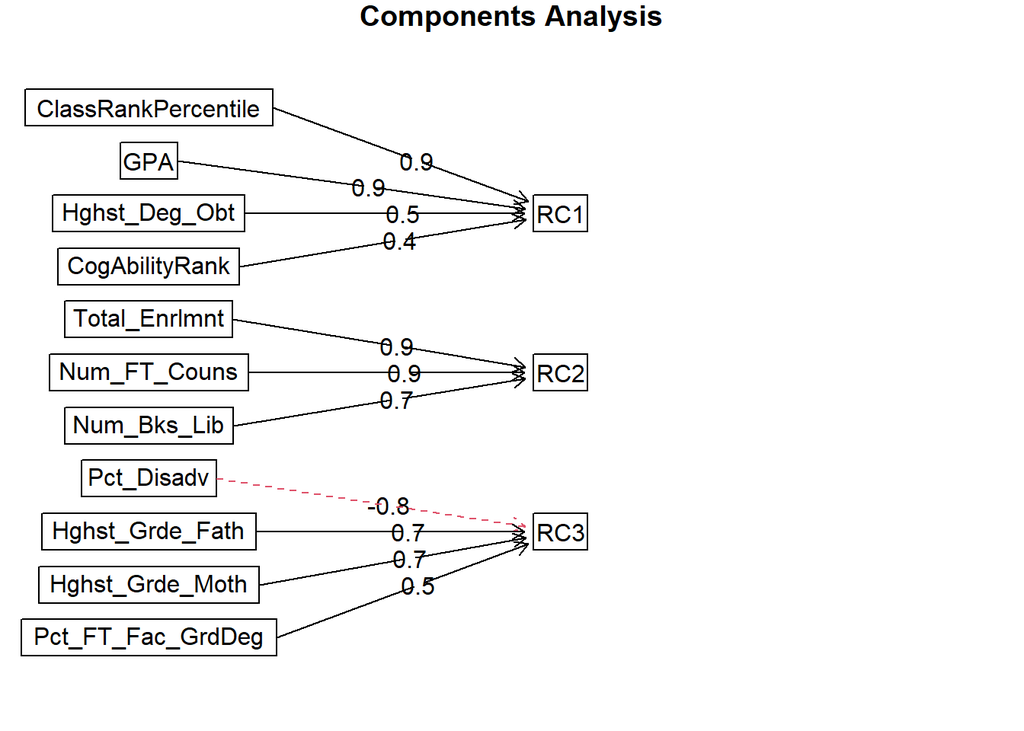

```r
# Plot results
fa.diagram(pca_final)
```

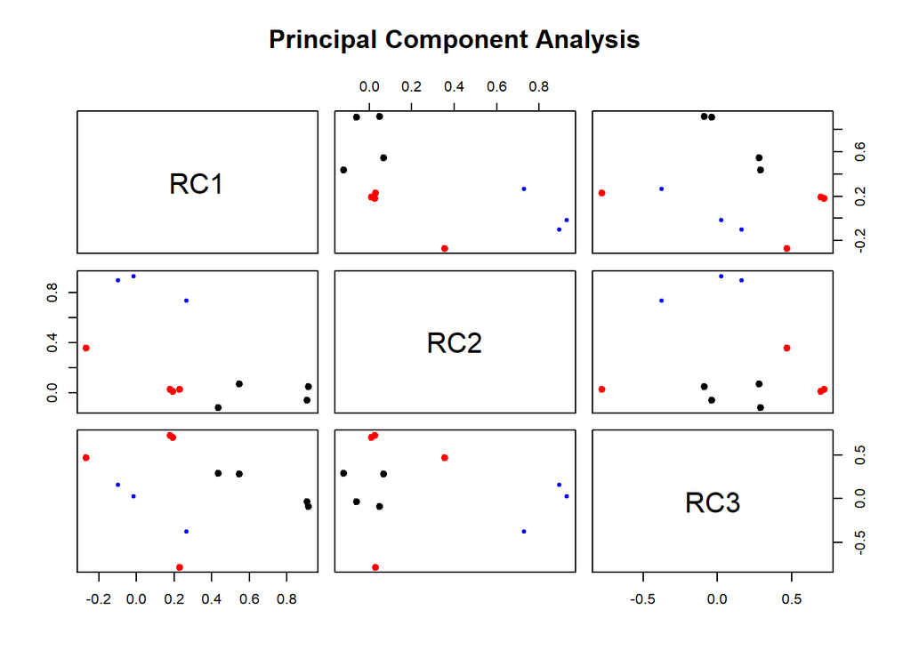

```r
plot(pca_final)
```

## 3.9 STEP 9: Collect factor scores

```r
#we need the pca scores
pca_final_scores <- as.data.frame(pca_final$scores)
head(pca_final_scores)
```

```
##           RC1        RC2       RC3
## 1  0.30401553  0.4680576 0.4280545
## 2 -0.28851805  1.5060784 0.9451966
## 3  0.42677674  1.5932930 1.8227487
## 4  0.55213614 -0.4949480 0.5534814
## 5  0.06240951 -0.4500242 0.4037360
## 6  1.21285251  0.5108749 1.4206963
```

```r
#rename columns
pca_final_scores <- pca_final_scores %>%
  rename(Ability_Level = RC1, School_Size = RC2, Childhood_SES = RC3)

#combine this dataframe with earlier dataframe (nlsy_sub)

str(nlsy_sub_rm_outliers)
```

```
## 'data.frame':    300 obs. of  18 variables:
##  $ Sex                : Factor w/ 2 levels "0","1": 1 2 2 2 2 1 1 1 1 1 ...
##  $ Hghst_Grde_Moth    : int  12 12 17 12 11 14 12 12 14 10 ...
##  $ Hghst_Grde_Fath    : int  12 12 16 9 9 16 16 12 12 8 ...
##  $ GPA                : num  2.66 2.54 3.03 3.31 2.59 ...
##  $ CogAbilityRank     : num  78 70 36 91 79 ...
##  $ Total_Enrlmnt      : int  1634 1761 1761 706 706 1874 1874 1874 1027 2117 ...
##  $ Num_Bks_Lib        : int  20000 29000 29000 5000 5000 13000 13000 13000 15000 13500 ...
##  $ Pct_Disadv         : int  10 0 0 24 24 3 3 3 10 9 ...
##  $ Pct_Dropout        : int  2 0 0 2 2 4 4 4 10 14 ...
##  $ Pct_Fac_Female     : int  43 47 47 51 51 46 46 46 40 40 ...
##  $ Num_FT_Couns       : int  5 7 7 4 4 5 5 5 3 6 ...
##  $ Pct_FT_Fac_GrdDeg  : int  46 90 90 90 90 65 65 65 70 90 ...
##  $ Headstart          : Factor w/ 2 levels "0","1": 1 1 1 1 1 1 1 1 1 1 ...
##  $ ClassRankPercentile: num  62.7 42.4 59.6 75.6 75.3 ...
##  $ Marital_Status     : Factor w/ 2 levels "0","1": 2 2 2 2 2 2 1 2 2 2 ...
##  $ Num_Kids_HH        : int  0 2 0 1 0 3 0 0 3 3 ...
##  $ Self_Inc_2009      : int  40000 140000 146000 110000 51000 3500 56500 104000 33000 6000 ...
##  $ Hghst_Deg_Obt      : Factor w/ 6 levels "0","1","2","3",..: 4 4 5 4 4 4 4 2 3 2 ...
##  - attr(*, "na.action")= 'omit' Named int [1:4774] 1 3 4 5 8 9 10 11 12 13 ...
##   ..- attr(*, "names")= chr [1:4774] "1" "3" "4" "5" ...
```

```r
final_data <- cbind(nlsy_sub_rm_outliers, pca_final_scores)
str(final_data)
```

```
## 'data.frame':    300 obs. of  21 variables:
##  $ Sex                : Factor w/ 2 levels "0","1": 1 2 2 2 2 1 1 1 1 1 ...
##  $ Hghst_Grde_Moth    : int  12 12 17 12 11 14 12 12 14 10 ...
##  $ Hghst_Grde_Fath    : int  12 12 16 9 9 16 16 12 12 8 ...
##  $ GPA                : num  2.66 2.54 3.03 3.31 2.59 ...
##  $ CogAbilityRank     : num  78 70 36 91 79 ...
##  $ Total_Enrlmnt      : int  1634 1761 1761 706 706 1874 1874 1874 1027 2117 ...
##  $ Num_Bks_Lib        : int  20000 29000 29000 5000 5000 13000 13000 13000 15000 13500 ...
##  $ Pct_Disadv         : int  10 0 0 24 24 3 3 3 10 9 ...
##  $ Pct_Dropout        : int  2 0 0 2 2 4 4 4 10 14 ...
##  $ Pct_Fac_Female     : int  43 47 47 51 51 46 46 46 40 40 ...
##  $ Num_FT_Couns       : int  5 7 7 4 4 5 5 5 3 6 ...
##  $ Pct_FT_Fac_GrdDeg  : int  46 90 90 90 90 65 65 65 70 90 ...
##  $ Headstart          : Factor w/ 2 levels "0","1": 1 1 1 1 1 1 1 1 1 1 ...
##  $ ClassRankPercentile: num  62.7 42.4 59.6 75.6 75.3 ...
##  $ Marital_Status     : Factor w/ 2 levels "0","1": 2 2 2 2 2 2 1 2 2 2 ...
##  $ Num_Kids_HH        : int  0 2 0 1 0 3 0 0 3 3 ...
##  $ Self_Inc_2009      : int  40000 140000 146000 110000 51000 3500 56500 104000 33000 6000 ...
##  $ Hghst_Deg_Obt      : Factor w/ 6 levels "0","1","2","3",..: 4 4 5 4 4 4 4 2 3 2 ...
##  $ Ability_Level      : num  0.304 -0.2885 0.4268 0.5521 0.0624 ...
##  $ School_Size        : num  0.468 1.506 1.593 -0.495 -0.45 ...
##  $ Childhood_SES      : num  0.428 0.945 1.823 0.553 0.404 ...
```

```r
write.csv(pca_final_scores,"pca_scores_final_df_nlsy.csv", row.names=FALSE)
```

# 4 Linear Regression with Stepwise Sequential Selection and Cross-validation

## 4.1 Separate by gender

```r
# For females:
final_data_F <- final_data  %>%
  filter(Sex == 0) # choose females only
nrow(final_data_F)
```

```
## [1] 158
```

```r
## For males:
final_data_M <- final_data  %>%
  filter(Sex == 1) # choose males only
nrow(final_data_M)
```

```
## [1] 142
```

## 4.2 Predicting income for females

```r
set.seed(31) # Set seed

# New variable to divide data into training and test set
final_data_F <- final_data_F %>%
  mutate(ID = row_number())

# Select training set
train_setF <- final_data_F %>%
  sample_frac(0.80) # 80% of sample for training set

# Select test set
# Anti-join to pull all else from dataset not in training set into test set
test_setF  <- anti_join(final_data_F, train_setF, by = 'ID')

# Remove unnecessary ID variable
train_setF <- train_setF %>%
  dplyr::select(-ID)
nrow(train_setF)
```

```
## [1] 126
```

```r
test_setF <- test_setF %>%
  dplyr::select(-ID)
nrow(test_setF)
```

```
## [1] 32
```

```r
set.seed(31) # Set seed
train.ctrl <- trainControl(method = "cv", number = 5, seeds = NULL) # Set up for 5-fold CV

set.seed(31) # Set seed
nlsyInc_lm_cv5_stepF <-train(Self_Inc_2009 ~ Ability_Level + School_Size + Childhood_SES +
                               Marital_Status + Num_Kids_HH + Headstart + Pct_Dropout + Pct_Fac_Female,
                         data = train_setF, # Utilize only the train set
                         method = "leapSeq", # Backward and forward selection
                         tuneGrid = data.frame(nvmax = 1:8), # using predictors that we have
                         trControl = train.ctrl) # 5-fold cross-validation as defined above

summary(nlsyInc_lm_cv5_stepF) # Summary of variable selection
```

```
## Subset selection object
## 8 Variables  (and intercept)
##                 Forced in Forced out
## Ability_Level       FALSE      FALSE
## School_Size         FALSE      FALSE
## Childhood_SES       FALSE      FALSE
## Marital_Status1     FALSE      FALSE
## Num_Kids_HH         FALSE      FALSE
## Headstart1          FALSE      FALSE
## Pct_Dropout         FALSE      FALSE
## Pct_Fac_Female      FALSE      FALSE
## 1 subsets of each size up to 2
## Selection Algorithm: 'sequential replacement'
##          Ability_Level School_Size Childhood_SES Marital_Status1 Num_Kids_HH
## 1  ( 1 ) "*"           " "         " "           " "             " "
## 2  ( 1 ) "*"           " "         "*"           " "             " "
##          Headstart1 Pct_Dropout Pct_Fac_Female
## 1  ( 1 ) " "        " "         " "
## 2  ( 1 ) " "        " "         " "
```

```r
# Determine best tuned model and examine RMSE and R^2
# RMSE is at its lowest here and R^2 is at its highest
nlsyInc_lm_cv5_stepF$results[nlsyInc_lm_cv5_stepF$bestTune[1, "nvmax"],]
```

```
##   nvmax     RMSE  Rsquared      MAE   RMSESD RsquaredSD    MAESD
## 2     2 30318.21 0.1159845 23093.56 1862.045 0.06427592 858.0414
```

```r
# Variables for the best model
round(coef(nlsyInc_lm_cv5_stepF$finalModel, nlsyInc_lm_cv5_stepF$bestTune[1,"nvmax"]),2)
```

```
##   (Intercept) Ability_Level Childhood_SES
##      44307.00       8092.36       4552.18
```

```r
# Examine summary for final model with training set
final_lm_Inc_F <- lm(Self_Inc_2009 ~ Ability_Level + Childhood_SES,
                     data = train_setF)
summary(final_lm_Inc_F)
```

```
##
## Call:
## lm(formula = Self_Inc_2009 ~ Ability_Level + Childhood_SES, data = train_setF)
##
## Residuals:
##    Min     1Q Median     3Q    Max
## -57089 -19175  -2072  14929 104404
##
## Coefficients:
##               Estimate Std. Error t value Pr(>|t|)
## (Intercept)      44307       2774  15.975  < 2e-16 ***
## Ability_Level     8092       2958   2.736  0.00715 **
## Childhood_SES     4552       2610   1.744  0.08360 .
## ---
## Signif. codes:  0 '***' 0.001 '**' 0.01 '*' 0.05 '.' 0.1 ' ' 1
##
## Residual standard error: 30430 on 123 degrees of freedom
## Multiple R-squared:  0.1059, Adjusted R-squared:  0.0914
## F-statistic: 7.287 on 2 and 123 DF,  p-value: 0.001021
```

```r
round(sqrt(mean(final_lm_Inc_F$residuals^2)),4) # RMSE
```

```
## [1] 30063.87
```

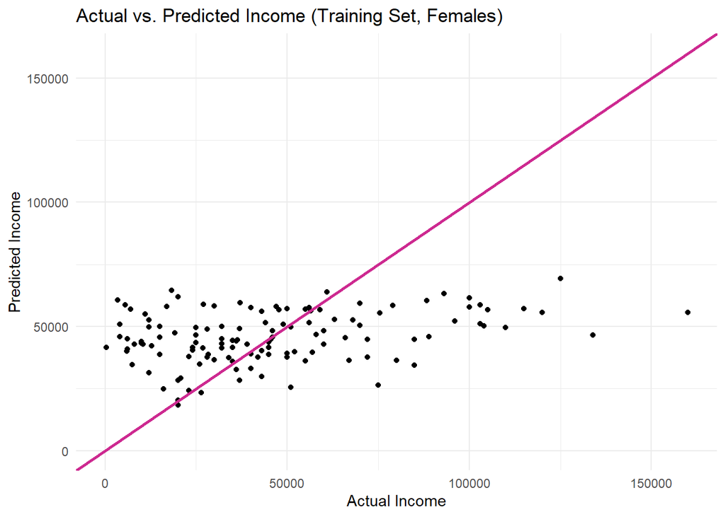

```r
# Examine actual vs. predicted values in training set
fitted_trainF <- predict(final_lm_Inc_F) # Pull fitted values
actual_trainF <- train_setF$Self_Inc_2009 # Pull actual values from training set
fitted_trainF <- unname(fitted_trainF) # Unname to have appropriate formatting for vector
act_fit_trainF <- cbind.data.frame(actual_trainF, fitted_trainF) # Create dataframe of actual vs. predicted

ggplot(act_fit_trainF, aes(x = actual_trainF, y = fitted_trainF)) + # Define data, x-axis, y-axis
  geom_point() + # To call scatterplot
  xlab("Actual Income") + # Label x-axis
  ylab("Predicted Income") + # Label y-axis
  ggtitle("Actual vs. Predicted Income (Training Set, Females)") + # Title
  geom_abline(color = "#CD2990", # Add line of equality
              linewidth = 1) +
  scale_x_continuous(limits = c(0, 160000)) + # Set range of x
  scale_y_continuous(limits = c(0, 160000)) + # Set range of y
  theme_minimal()
```

### 4.2.1 Validate on holdout test set

```r
## Gather predicted values for test set, females
test_predictF <- predict(final_lm_Inc_F, test_setF)

corr_testF <- cor(test_predictF, test_setF$Self_Inc_2009) # Correlation between actual and predicted GPAs in test set
round(corr_testF,4) # Correlation between actual and predicted values
```

```
## [1] 0.2984
```

```r
round(corr_testF^2,4) # Square for comparison to R^2 in original model on training set,
```

```
## [1] 0.0891
```

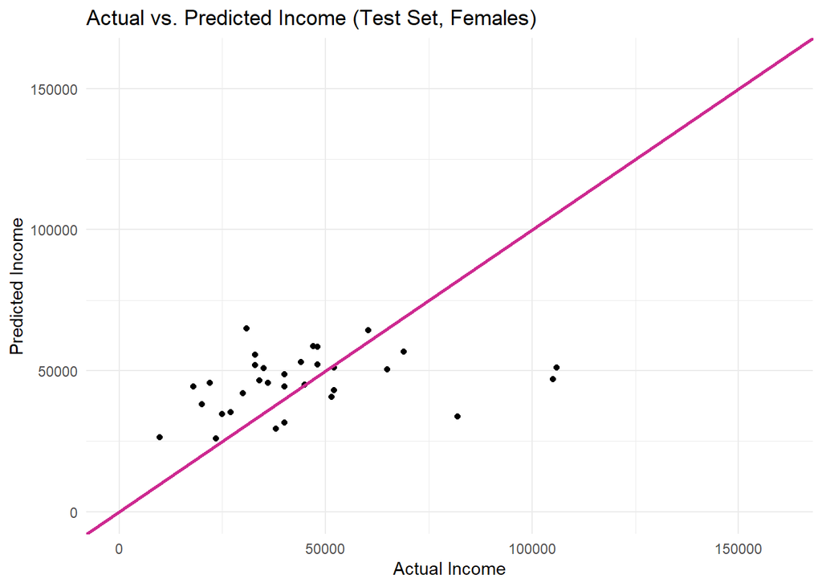

```r
# Compare actual vs. predicted in test set
actual_testF <- test_setF$Self_Inc_2009
act_fit_testF <- cbind.data.frame(actual_testF, test_predictF) # Dataframe of actual vs. predicted for test set

ggplot(act_fit_testF, aes(x = actual_testF, y = test_predictF)) + # Call data, x-axis, y-axis
  geom_point() + # To call scatterplot
  xlab("Actual Income") + # Label axes
  ylab("Predicted Income") +
  ggtitle("Actual vs. Predicted Income (Test Set, Females)") + # Title
  geom_abline(color = "#CD2990", # Set up line of equality
              linewidth = 1) +
  scale_x_continuous(limits = c(0, 160000)) +
  scale_y_continuous(limits = c(0, 160000)) + # Set consistent range for axes
  theme_minimal()
```

## 4.3 Predicting income for males

```r
set.seed(31) # Set seed

# New variable to divide data into training and test set
final_data_M <- final_data_M %>%
  mutate(ID = row_number())

# Select training set
train_setM <- final_data_M %>%
  sample_frac(0.8) # 80% of sample for training set

# Select test set
# Anti-join to pull all else from dataset not in training set into test set
test_setM  <- anti_join(final_data_M, train_setM, by = 'ID')

# Remove unnecessary ID variable
train_setM <- train_setM %>%
  dplyr::select(-ID)
nrow(train_setM)
```

```
## [1] 114
```

```r
test_setM <- test_setM %>%
  dplyr::select(-ID)
nrow(test_setM)
```

```
## [1] 28
```

```r
set.seed(31) # Set seed
train.ctrl <- trainControl(method = "cv", number = 5, seeds = NULL) # Set up for 5-fold CV

set.seed(31) # Set seed
nlsyInc_lm_cv5_stepM <-train(Self_Inc_2009 ~ Ability_Level + School_Size + Childhood_SES +
                                 Marital_Status + Num_Kids_HH + Headstart + Pct_Dropout +
                                 Pct_Fac_Female,
                         data = train_setM, # Utilize only the train set
                         method = "leapSeq", # Backward and forward selection
                         tuneGrid = data.frame(nvmax = 1:8), # using predictors that we have
                         trControl = train.ctrl) # 5-fold cross-validation as defined above

summary(nlsyInc_lm_cv5_stepM) # Summary of variable selection
```

```
## Subset selection object
## 8 Variables  (and intercept)
##                 Forced in Forced out
## Ability_Level       FALSE      FALSE
## School_Size         FALSE      FALSE
## Childhood_SES       FALSE      FALSE
## Marital_Status1     FALSE      FALSE
## Num_Kids_HH         FALSE      FALSE
## Headstart1          FALSE      FALSE
## Pct_Dropout         FALSE      FALSE
## Pct_Fac_Female      FALSE      FALSE
## 1 subsets of each size up to 2
## Selection Algorithm: 'sequential replacement'
##          Ability_Level School_Size Childhood_SES Marital_Status1 Num_Kids_HH
## 1  ( 1 ) "*"           " "         " "           " "             " "
## 2  ( 1 ) "*"           " "         " "           " "             "*"
##          Headstart1 Pct_Dropout Pct_Fac_Female
## 1  ( 1 ) " "        " "         " "
## 2  ( 1 ) " "        " "         " "
```

```r
# Determine best tuned model and examine RMSE and R^2
# RMSE is at its lowest here and R^2 is at its highest
nlsyInc_lm_cv5_stepM$results[nlsyInc_lm_cv5_stepM$bestTune[1, "nvmax"],]
```

```
##   nvmax    RMSE  Rsquared      MAE   RMSESD RsquaredSD    MAESD
## 2     2 33707.3 0.2479403 26805.77 4256.851   0.187879 3235.348
```

```r
# Variables for the best model
round(coef(nlsyInc_lm_cv5_stepM$finalModel, nlsyInc_lm_cv5_stepM$bestTune[1,"nvmax"]),2)
```

```
##   (Intercept) Ability_Level   Num_Kids_HH
##      53107.30      13009.51       8695.09
```

```r
# Examine summary for final model with training set
final_lm_Inc_M <- lm(Self_Inc_2009 ~ Ability_Level + Num_Kids_HH,
                     data = train_setM)
summary(final_lm_Inc_M)
```

```
##
## Call:
## lm(formula = Self_Inc_2009 ~ Ability_Level + Num_Kids_HH, data = train_setM)
##
## Residuals:
##    Min     1Q Median     3Q    Max
## -70834 -22606   1280  18782  87341
##
## Coefficients:
##               Estimate Std. Error t value Pr(>|t|)
## (Intercept)      53107       4593  11.563  < 2e-16 ***
## Ability_Level    13010       3178   4.093  8.1e-05 ***
## Num_Kids_HH       8695       2672   3.254  0.00151 **
## ---
## Signif. codes:  0 '***' 0.001 '**' 0.01 '*' 0.05 '.' 0.1 ' ' 1
##
## Residual standard error: 33320 on 111 degrees of freedom
## Multiple R-squared:  0.2292, Adjusted R-squared:  0.2153
## F-statistic:  16.5 on 2 and 111 DF,  p-value: 5.322e-07
```

```r
round(sqrt(mean(final_lm_Inc_M$residuals^2)),4) # RMSE
```

```
## [1] 32876.92
```

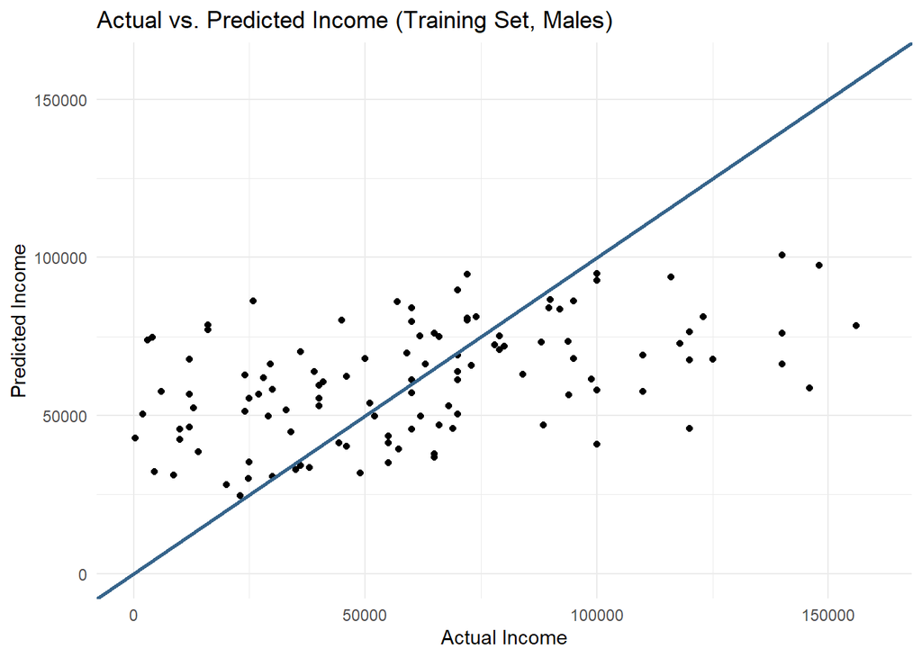

```r
# Examine actual vs. predicted values in training set
fitted_trainM <- predict(final_lm_Inc_M) # Pull fitted values
actual_trainM <- train_setM$Self_Inc_2009 # Pull actual values from training set
fitted_trainM <- unname(fitted_trainM) # Unname to have appropriate formatting for vector
act_fit_trainM <- cbind.data.frame(actual_trainM, fitted_trainM) # Create dataframe of actual vs. predicted

ggplot(act_fit_trainM, aes(x = actual_trainM, y = fitted_trainM)) + # Define data, x-axis, y-axis
  geom_point() + # To call scatterplot
  xlab("Actual Income") + # Label x-axis
  ylab("Predicted Income") + # Label y-axis
  ggtitle("Actual vs. Predicted Income (Training Set, Males)") + # Title
  geom_abline(color = "#36648B", # Add line of equality
              linewidth = 1) +
  scale_x_continuous(limits = c(0, 160000)) + # Set range of x
  scale_y_continuous(limits = c(0, 160000)) + # Set range of y
  theme_minimal()
```

### 4.3.1 Validate on holdout test set

```r
# Gather predicted values for test set, males
test_predictM <- predict(final_lm_Inc_M, test_setM)

corr_testM <- cor(test_predictM, test_setM$Self_Inc_2009) # Correlation between actual and predicted GPAs in test set
round(corr_testM,4) # Correlation between actual and predicted values
```

```
## [1] 0.2533
```

```r
round(corr_testM^2,4) # Square for comparison to R^2 in original model on training set
```

```
## [1] 0.0641
```

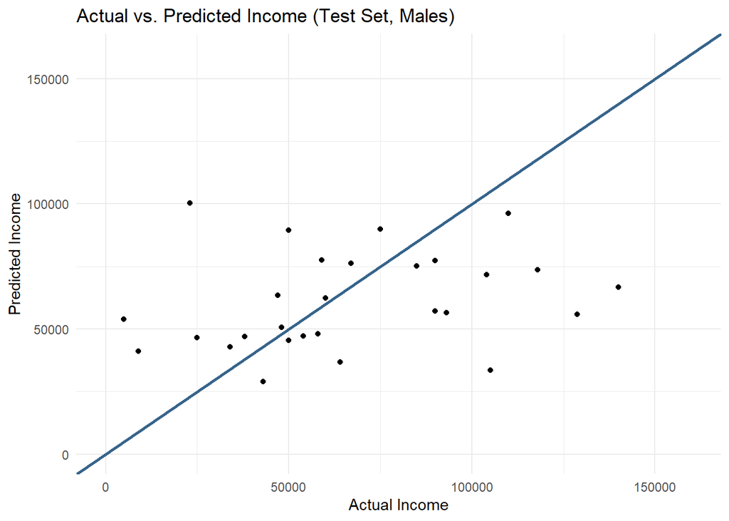

```r
# Compare actual vs. predicted in test set
actual_testM <- test_setM$Self_Inc_2009
act_fit_testM <- cbind.data.frame(actual_testM, test_predictM) # Dataframe of actual vs. predicted for test set

ggplot(act_fit_testM, aes(x = actual_testM, y = test_predictM)) + # Call data, x-axis, y-axis
  geom_point() + # To call scatterplot
  xlab("Actual Income") + # Label axes
  ylab("Predicted Income") +
  ggtitle("Actual vs. Predicted Income (Test Set, Males)") + # Title
  geom_abline(color = "#36648B", # Set up line of equality
              linewidth = 1) +
  scale_x_continuous(limits = c(0, 160000)) +
  scale_y_continuous(limits = c(0, 160000)) + # Set consistent range for axes
  theme_minimal()
```